# Foreign Aid & the World's Least Developed Countries (LDCs)

## Is Foreign Aid Correlated With Economic & Human Development?

#### Carl Smith

**June 2020**

> - Introduction
> - Data Wrangling
> - Exploratory Data Analysis
> - Conclusions

## Introduction

> The data set that was chosen for this analysis was the Gapminder World data set. Specifically, I used the following data tables in the Gapminder data set:
> - Foreign Aid Received per capita (current USD$)
> - Human Devlopment Index (HDI)
> - Gini Coefficient
> - Total Fertility Rate

> I chose these because I was genuinely interested in seeing if there was any correlation between the amount of foreign aid a country receives and economic indicators such as HDI, Gini Coefficient, and Fertility rates.

> I focused all foreign aid anlaysis on a per capita basis, in order to gain a better insight into how the data affects individual citizens in these countries.

> In addition, I will be analyzing data from 2000 to 2018. The data in this timeframe is the most complete and most recent data available from the Gapminder data set.

> Finally, I chose to do my analysis on a subset of countries called LDCs, or Least Developed Countries. These are countries defined by the UN who have a GNI per capita less than $1,025, in addition to other factors such as the Human Assets Index and the Economic Vulnerability Index. I decided to focus on this subset of countries because their economies are very dependent on foreign aid, when compared to non-LDCs who also receive foreign aid. This is important to my analysis, because it allows me to isolate the dependent varibale, foreign aid, as much as possible. In other words, since I am anlayzing countries who rely more on foreign aid, any correlations found between the amount of foreign aid and other economic indicators, will be more statistically significant.

### Reasearch Question 1

> - Is there a positive correlation between the amount of foreign aid per capita an LDC country receives, and the economic indicators: HDI, Gini coefficient, and fertility rates?

### Research Question 2

> - Does the amount of foreign aid per capita have any impact on the strength of this correlation? In other words, does a country who receives more foreign aid per capita see a stronger correlation with the economic indicators, than a country who receives less foreign aid per capita?

```python
import pandas as pd
import numpy as np
import matplotlib.pyplot as plt
import seaborn as sns
%matplotlib inline
```

## Data Wrangling

> In this section I will importing all of the csv files used during this analysis. I will then clean them into several different dataframes that I will use throughout the Exploratory Data Analysis section.

### General Properties

> First let's take a look at foreign aid per capita data.

```python
df = pd.read_csv('aid_received_per_capita.csv')
df.set_index('country', inplace=True)       # Let's just set the index to country quickly.
df.head()
```

| country | 1960 | 1961 | 1962 | 1963 | 1964 | 1965 | 1966 | 1967 | 1968 | 1969 | ... | 2009 | 2010 | 2011 | 2012 | 2013 | 2014 | 2015 | 2016 | 2017 | 2018 |
| --- | --- | --- | --- | --- | --- | --- | --- | --- | --- | --- | --- | --- | --- | --- | --- | --- | --- | --- | --- | --- | --- |
| Afghanistan | 1.91000 | 3.78 | 1.81 | 3.84000 | 4.74 | 5.420 | 5.000 | 3.95 | 2.75000 | 2.500 | ... | 215.00 | 214.00 | 224.00 | 214.00 | 160.00 | 148.00 | 124.00 | 115.000 | 105.00 | 102.00 |
| Albania | NaN | NaN | NaN | NaN | NaN | NaN | NaN | NaN | NaN | NaN | ... | 122.00 | 125.00 | 131.00 | 120.00 | 93.30 | 97.30 | 116.00 | 59.500 | 58.50 | 120.00 |
| Algeria | 32.10000 | 38.60 | 34.20 | 23.70000 | 18.60 | 11.700 | 9.840 | 8.11 | 8.75000 | 9.330 | ... | 8.56 | 5.59 | 5.27 | 3.94 | 5.33 | 4.13 | 1.79 | 3.560 | 4.22 | 3.41 |
| Angola | -0.00917 | 4.26 | NaN | 0.00528 | NaN | 0.192 | 0.495 | 3.15 | 0.00173 | -0.019 | ... | 10.60 | 10.10 | 7.97 | 9.70 | 11.00 | 8.74 | 13.60 | 7.160 | 7.49 | 5.18 |
| Antigua and Barbuda | NaN | NaN | NaN | NaN | NaN | NaN | NaN | NaN | NaN | NaN | ... | 49.10 | 223.00 | 173.00 | 23.10 | 17.40 | 27.50 | 15.90 | 0.635 | 104.00 | 174.00 |

5 rows × 59 columns

```python
df.shape
```

[output not shown]

```python
# Ok, so we have some null values that we will probably have to deal with.
df.isna().sum().sum()
```

```
1455
```

```python
# dtypes look clean.
df.info()
```

[output not shown]

[output cut: 52 more lines]

> Next, let's look at HDI, Gini, and fertility rates.

```python
df_hdi = pd.read_csv('hdi.csv')
df_hdi.set_index('country', inplace=True)
df_hdi.head()
```

| country | 1990 | 1991 | 1992 | 1993 | 1994 | 1995 | 1996 | 1997 | 1998 | 1999 | ... | 2006 | 2007 | 2008 | 2009 | 2010 | 2011 | 2012 | 2013 | 2014 | 2015 |
| --- | --- | --- | --- | --- | --- | --- | --- | --- | --- | --- | --- | --- | --- | --- | --- | --- | --- | --- | --- | --- | --- |
| Afghanistan | 0.295 | 0.300 | 0.309 | 0.305 | 0.300 | 0.324 | 0.328 | 0.332 | 0.335 | 0.338 | ... | 0.415 | 0.433 | 0.434 | 0.448 | 0.454 | 0.463 | 0.470 | 0.476 | 0.479 | 0.479 |
| Albania | 0.635 | 0.618 | 0.603 | 0.608 | 0.616 | 0.628 | 0.637 | 0.636 | 0.646 | 0.656 | ... | 0.703 | 0.713 | 0.721 | 0.725 | 0.738 | 0.752 | 0.759 | 0.761 | 0.762 | 0.764 |
| Algeria | 0.577 | 0.581 | 0.587 | 0.591 | 0.595 | 0.600 | 0.609 | 0.617 | 0.627 | 0.636 | ... | 0.690 | 0.697 | 0.705 | 0.714 | 0.724 | 0.732 | 0.737 | 0.741 | 0.743 | 0.745 |
| Andorra | NaN | NaN | NaN | NaN | NaN | NaN | NaN | NaN | NaN | NaN | ... | NaN | NaN | NaN | NaN | 0.819 | 0.819 | 0.843 | 0.850 | 0.857 | 0.858 |
| Angola | NaN | NaN | NaN | NaN | NaN | NaN | NaN | NaN | NaN | 0.382 | ... | 0.454 | 0.468 | 0.480 | 0.488 | 0.495 | 0.508 | 0.523 | 0.527 | 0.531 | 0.533 |

5 rows × 26 columns

> Looks like HDI data is missing values from 2016-2018, I will need to find these and append them or something.

```python
# Gini coefficient data
df_gini = pd.read_csv('gini.csv')
df_gini.set_index('country', inplace=True)
df_gini
```

| country | 1800 | 1801 | 1802 | 1803 | 1804 | 1805 | 1806 | 1807 | 1808 | 1809 | ... | 2031 | 2032 | 2033 | 2034 | 2035 | 2036 | 2037 | 2038 | 2039 | 2040 |
| --- | --- | --- | --- | --- | --- | --- | --- | --- | --- | --- | --- | --- | --- | --- | --- | --- | --- | --- | --- | --- | --- |
| Afghanistan | 30.5 | 30.5 | 30.5 | 30.5 | 30.5 | 30.5 | 30.5 | 30.5 | 30.5 | 30.5 | ... | 36.8 | 36.8 | 36.8 | 36.8 | 36.8 | 36.8 | 36.8 | 36.8 | 36.8 | 36.8 |
| Albania | 38.9 | 38.9 | 38.9 | 38.9 | 38.9 | 38.9 | 38.9 | 38.9 | 38.9 | 38.9 | ... | 29.0 | 29.0 | 29.0 | 29.0 | 29.0 | 29.0 | 29.0 | 29.0 | 29.0 | 29.0 |
| Algeria | 56.2 | 56.2 | 56.2 | 56.2 | 56.2 | 56.2 | 56.2 | 56.2 | 56.2 | 56.2 | ... | 27.6 | 27.6 | 27.6 | 27.6 | 27.6 | 27.6 | 27.6 | 27.6 | 27.6 | 27.6 |
| Andorra | 40.0 | 40.0 | 40.0 | 40.0 | 40.0 | 40.0 | 40.0 | 40.0 | 40.0 | 40.0 | ... | 40.0 | 40.0 | 40.0 | 40.0 | 40.0 | 40.0 | 40.0 | 40.0 | 40.0 | 40.0 |
| Angola | 57.2 | 57.2 | 57.2 | 57.2 | 57.2 | 57.2 | 57.2 | 57.2 | 57.2 | 57.2 | ... | 42.6 | 42.6 | 42.6 | 42.6 | 42.6 | 42.6 | 42.6 | 42.6 | 42.6 | 42.6 |
| ... | ... | ... | ... | ... | ... | ... | ... | ... | ... | ... | ... | ... | ... | ... | ... | ... | ... | ... | ... | ... | ... |
| Venezuela | 62.8 | 62.8 | 62.8 | 62.8 | 62.8 | 62.8 | 62.8 | 62.8 | 62.8 | 62.8 | ... | 46.9 | 46.9 | 46.9 | 46.9 | 46.9 | 46.9 | 46.9 | 46.9 | 46.9 | 46.9 |
| Vietnam | 34.2 | 34.2 | 34.2 | 34.2 | 34.2 | 34.2 | 34.2 | 34.2 | 34.2 | 34.2 | ... | 35.3 | 35.3 | 35.3 | 35.3 | 35.3 | 35.3 | 35.3 | 35.3 | 35.3 | 35.3 |
| Yemen | 50.1 | 50.1 | 50.1 | 50.1 | 50.1 | 50.1 | 50.1 | 50.1 | 50.1 | 50.1 | ... | 36.7 | 36.7 | 36.7 | 36.7 | 36.7 | 36.7 | 36.7 | 36.7 | 36.7 | 36.7 |
| Zambia | 54.5 | 54.5 | 54.5 | 54.5 | 54.5 | 54.5 | 54.5 | 54.5 | 54.5 | 54.5 | ... | 57.1 | 57.1 | 57.1 | 57.1 | 57.1 | 57.1 | 57.1 | 57.1 | 57.1 | 57.1 |
| Zimbabwe | 27.5 | 27.5 | 27.5 | 27.5 | 27.5 | 27.5 | 27.5 | 27.5 | 27.5 | 27.5 | ... | 43.2 | 43.2 | 43.2 | 43.2 | 43.2 | 43.2 | 43.2 | 43.2 | 43.2 | 43.2 |

195 rows × 241 columns

> Looks clean as a whistle!

```python
# Fertility rates data
df_fertility = pd.read_csv('fertility_rates.csv')
df_fertility.set_index('country', inplace=True)
df_fertility
```

| country | 1800 | 1801 | 1802 | 1803 | 1804 | 1805 | 1806 | 1807 | 1808 | 1809 | ... | 2091 | 2092 | 2093 | 2094 | 2095 | 2096 | 2097 | 2098 | 2099 | 2100 |
| --- | --- | --- | --- | --- | --- | --- | --- | --- | --- | --- | --- | --- | --- | --- | --- | --- | --- | --- | --- | --- | --- |
| Afghanistan | 7.00 | 7.00 | 7.00 | 7.00 | 7.00 | 7.00 | 7.00 | 7.00 | 7.00 | 7.00 | ... | 1.74 | 1.74 | 1.74 | 1.74 | 1.74 | 1.74 | 1.74 | 1.74 | 1.74 | 1.74 |
| Albania | 4.60 | 4.60 | 4.60 | 4.60 | 4.60 | 4.60 | 4.60 | 4.60 | 4.60 | 4.60 | ... | 1.78 | 1.78 | 1.78 | 1.79 | 1.79 | 1.79 | 1.79 | 1.79 | 1.79 | 1.79 |
| Algeria | 6.99 | 6.99 | 6.99 | 6.99 | 6.99 | 6.99 | 6.99 | 6.99 | 6.99 | 6.99 | ... | 1.86 | 1.86 | 1.86 | 1.86 | 1.86 | 1.86 | 1.86 | 1.86 | 1.86 | 1.86 |
| Angola | 6.93 | 6.93 | 6.93 | 6.93 | 6.93 | 6.93 | 6.93 | 6.94 | 6.94 | 6.94 | ... | 2.54 | 2.52 | 2.50 | 2.48 | 2.47 | 2.45 | 2.43 | 2.42 | 2.40 | 2.40 |
| Antigua and Barbuda | 5.00 | 5.00 | 4.99 | 4.99 | 4.99 | 4.98 | 4.98 | 4.97 | 4.97 | 4.97 | ... | 1.81 | 1.81 | 1.81 | 1.81 | 1.81 | 1.81 | 1.81 | 1.82 | 1.82 | 1.82 |
| ... | ... | ... | ... | ... | ... | ... | ... | ... | ... | ... | ... | ... | ... | ... | ... | ... | ... | ... | ... | ... | ... |
| Venezuela | 5.63 | 5.63 | 5.64 | 5.64 | 5.64 | 5.65 | 5.65 | 5.65 | 5.66 | 5.66 | ... | 1.78 | 1.78 | 1.78 | 1.79 | 1.79 | 1.79 | 1.79 | 1.79 | 1.79 | 1.79 |
| Vietnam | 4.70 | 4.70 | 4.70 | 4.70 | 4.70 | 4.70 | 4.70 | 4.70 | 4.70 | 4.70 | ... | 1.89 | 1.89 | 1.89 | 1.89 | 1.89 | 1.89 | 1.89 | 1.89 | 1.89 | 1.89 |
| Yemen | 6.88 | 6.88 | 6.88 | 6.88 | 6.88 | 6.88 | 6.88 | 6.88 | 6.88 | 6.88 | ... | 1.68 | 1.68 | 1.69 | 1.69 | 1.69 | 1.69 | 1.70 | 1.70 | 1.70 | 1.70 |
| Zambia | 6.71 | 6.71 | 6.71 | 6.71 | 6.71 | 6.71 | 6.71 | 6.71 | 6.71 | 6.71 | ... | 2.59 | 2.57 | 2.56 | 2.54 | 2.53 | 2.51 | 2.50 | 2.48 | 2.46 | 2.46 |
| Zimbabwe | 6.75 | 6.75 | 6.75 | 6.75 | 6.75 | 6.75 | 6.75 | 6.75 | 6.75 | 6.75 | ... | 1.85 | 1.85 | 1.85 | 1.84 | 1.84 | 1.84 | 1.83 | 1.83 | 1.83 | 1.83 |

184 rows × 301 columns

> df_fertility also looks very clean.

### Data Cleaning

> Now that I have general dataframes imported, I can shave them down the data that I need to for my analysis.

> First I will isolate the LDC countries and the timeframe 2000-2018.

```python
# before I create an LDC dataframe, I will create a list variable for LDC countries.

ldc = ['Afghanistan', 'Angola', 'Bangladesh', 'Benin', 'Bhutan','Burkina Faso', 'Burundi', 'Cambodia',
'Central African Republic', 'Chad', 'Comoros', 'Congo, Dem. Rep.', 'Djibouti', 'Eritrea',
'Ethiopia', 'Gambia', 'Guinea', 'Guinea-Bissau', 'Haiti', 'Kiribati', 'Lao', 'Lesotho', 'Liberia', 'Madagascar', 'Malawi',
'Mali', 'Mauritania', 'Mozambique', 'Myanmar', 'Nepal', 'Niger', 'Rwanda', 'Sao Tome and Principe', 'Senegal', 'Sierra Leone',
'Solomon Islands', 'Somalia', 'Sudan', 'Tanzania', 'Togo', 'Uganda', 'Vanuatu', 'Yemen', 'Zambia']
```

```python
# now I can create the LDC dataframe for aid per capita.
df_ldc = df.loc[ldc, '2000':'2018']
df_ldc.head()
```

| country | 2000 | 2001 | 2002 | 2003 | 2004 | 2005 | 2006 | 2007 | 2008 | 2009 | 2010 | 2011 | 2012 | 2013 | 2014 | 2015 | 2016 | 2017 | 2018 |
| --- | --- | --- | --- | --- | --- | --- | --- | --- | --- | --- | --- | --- | --- | --- | --- | --- | --- | --- | --- |
| Afghanistan | 6.55 | 19.00 | 54.10 | 65.00 | 91.7 | 110.0 | 110.00 | 184.00 | 174.0 | 215.00 | 214.00 | 224.00 | 214.0 | 160.0 | 148.00 | 124.0 | 115.00 | 105.00 | 102.00 |
| Angola | 18.40 | 16.70 | 23.60 | 27.20 | 61.0 | 21.3 | 8.12 | 12.40 | 17.0 | 10.60 | 10.10 | 7.97 | 9.7 | 11.0 | 8.74 | 13.6 | 7.16 | 7.49 | 5.18 |
| Bangladesh | 7.65 | 7.06 | 6.09 | 9.66 | 10.4 | 9.0 | 7.29 | 9.17 | 12.2 | 7.42 | 8.99 | 9.63 | 14.3 | 17.2 | 15.70 | 16.6 | 16.00 | 23.70 | 18.80 |
| Benin | 35.60 | 39.60 | 30.40 | 40.20 | 50.6 | 43.7 | 48.70 | 56.20 | 73.2 | 75.70 | 74.90 | 71.10 | 52.2 | 66.0 | 58.30 | 41.3 | 46.10 | 60.80 | 49.70 |
| Bhutan | 79.70 | 90.50 | 97.40 | 116.00 | 113.0 | 121.0 | 141.00 | 144.00 | 118.0 | 149.00 | 142.00 | 171.00 | 230.0 | 193.0 | 182.00 | 134.0 | 70.00 | 159.00 | 133.00 |

```python
# any missing values?
df_ldc[df_ldc.isna().any(axis=1)]
```

| country | 2000 | 2001 | 2002 | 2003 | 2004 | 2005 | 2006 | 2007 | 2008 | 2009 | 2010 | 2011 | 2012 | 2013 | 2014 | 2015 | 2016 | 2017 | 2018 |
| --- | --- | --- | --- | --- | --- | --- | --- | --- | --- | --- | --- | --- | --- | --- | --- | --- | --- | --- | --- |
| Eritrea | 77.70 | 120.00 | 91.40 | 122.0 | 96.9 | 124.0 | 43.2 | 52.9 | 47.5 | 45.7 | 51.2 | 41.5 | NaN | NaN | NaN | NaN | NaN | NaN | NaN |
| Sudan | 6.48 | 5.37 | 8.29 | 16.4 | 25.5 | 45.6 | 49.7 | 50.0 | 58.8 | 52.4 | 43.9 | 47.2 | 36.3 | 39.1 | 22.2 | 22.4 | 19.7 | 19.9 | NaN |

```python
# there aren't that many missing values so I will impute w/ mean.

df_ldc = df_ldc.apply(lambda row: row.fillna(row.mean()), axis=1).round(2)
df_ldc.head()
```

| country | 2000 | 2001 | 2002 | 2003 | 2004 | 2005 | 2006 | 2007 | 2008 | 2009 | 2010 | 2011 | 2012 | 2013 | 2014 | 2015 | 2016 | 2017 | 2018 |
| --- | --- | --- | --- | --- | --- | --- | --- | --- | --- | --- | --- | --- | --- | --- | --- | --- | --- | --- | --- |
| Afghanistan | 6.55 | 19.00 | 54.10 | 65.00 | 91.7 | 110.0 | 110.00 | 184.00 | 174.0 | 215.00 | 214.00 | 224.00 | 214.0 | 160.0 | 148.00 | 124.0 | 115.00 | 105.00 | 102.00 |
| Angola | 18.40 | 16.70 | 23.60 | 27.20 | 61.0 | 21.3 | 8.12 | 12.40 | 17.0 | 10.60 | 10.10 | 7.97 | 9.7 | 11.0 | 8.74 | 13.6 | 7.16 | 7.49 | 5.18 |
| Bangladesh | 7.65 | 7.06 | 6.09 | 9.66 | 10.4 | 9.0 | 7.29 | 9.17 | 12.2 | 7.42 | 8.99 | 9.63 | 14.3 | 17.2 | 15.70 | 16.6 | 16.00 | 23.70 | 18.80 |
| Benin | 35.60 | 39.60 | 30.40 | 40.20 | 50.6 | 43.7 | 48.70 | 56.20 | 73.2 | 75.70 | 74.90 | 71.10 | 52.2 | 66.0 | 58.30 | 41.3 | 46.10 | 60.80 | 49.70 |
| Bhutan | 79.70 | 90.50 | 97.40 | 116.00 | 113.0 | 121.0 | 141.00 | 144.00 | 118.0 | 149.00 | 142.00 | 171.00 | 230.0 | 193.0 | 182.00 | 134.0 | 70.00 | 159.00 | 133.00 |

```python
# confirm all missing values are filled.
df_ldc.isna().sum().sum()
```

```
0
```

> Now, in order to answer my second research question, I am going to seperate the LDC countries into two groups. One group will consist of countries who receive the most amount of foreign aid per capita on average, and the other will be those countries who receive the least on average. I will define these two groups by finding which countries fall in the upper quartile of aid received, and which countries fall in the lower quartile of aid received. By doing this I will be able to compare these two groups to see how their correlations are affected based on the amount of foreign aid they receive.

```python
# let's first find the average amount of aid each country has received from 2000 to 2018.

ldc_means = []

for country in ldc:
    mean_ldc = df_ldc.loc[country].mean()
    ldc_means.append(mean_ldc)

ldc_means[:10]
```

```
[128.17631578947368,
 15.645263157894739,
 11.939999999999998,
 53.38421052631579,
 135.97894736842105,
 54.468421052631584,
 49.436842105263146,
 42.52631578947369,
 59.91052631578947,
 35.57368421052632]
```

```python
# Now let's add the means to the dataframe so that we can .describe()
df_ldc['ldc_means'] = df_ldc.mean(axis=1).round(2)
df_ldc.head()
```

| country | 2000 | 2001 | 2002 | 2003 | 2004 | 2005 | 2006 | 2007 | 2008 | 2009 | 2010 | 2011 | 2012 | 2013 | 2014 | 2015 | 2016 | 2017 | 2018 | ldc_means |
| --- | --- | --- | --- | --- | --- | --- | --- | --- | --- | --- | --- | --- | --- | --- | --- | --- | --- | --- | --- | --- |
| Afghanistan | 6.55 | 19.00 | 54.10 | 65.00 | 91.7 | 110.0 | 110.00 | 184.00 | 174.0 | 215.00 | 214.00 | 224.00 | 214.0 | 160.0 | 148.00 | 124.0 | 115.00 | 105.00 | 102.00 | 128.18 |
| Angola | 18.40 | 16.70 | 23.60 | 27.20 | 61.0 | 21.3 | 8.12 | 12.40 | 17.0 | 10.60 | 10.10 | 7.97 | 9.7 | 11.0 | 8.74 | 13.6 | 7.16 | 7.49 | 5.18 | 15.65 |
| Bangladesh | 7.65 | 7.06 | 6.09 | 9.66 | 10.4 | 9.0 | 7.29 | 9.17 | 12.2 | 7.42 | 8.99 | 9.63 | 14.3 | 17.2 | 15.70 | 16.6 | 16.00 | 23.70 | 18.80 | 11.94 |
| Benin | 35.60 | 39.60 | 30.40 | 40.20 | 50.6 | 43.7 | 48.70 | 56.20 | 73.2 | 75.70 | 74.90 | 71.10 | 52.2 | 66.0 | 58.30 | 41.3 | 46.10 | 60.80 | 49.70 | 53.38 |
| Bhutan | 79.70 | 90.50 | 97.40 | 116.00 | 113.0 | 121.0 | 141.00 | 144.00 | 118.0 | 149.00 | 142.00 | 171.00 | 230.0 | 193.0 | 182.00 | 134.0 | 70.00 | 159.00 | 133.00 | 135.98 |

```python
# Now we can find the values that will define our quartiles.
df_ldc.ldc_means.describe()
```

```
count     44.000000
mean      85.531364
std       86.771819
min       11.940000
25%       38.980000
50%       58.545000
75%       77.082500
max      395.630000
Name: ldc_means, dtype: float64
```

> Now we can make seperate dataframes for countries the fall within the upper quartile and countries that fall within the lower quartile.

```python
df_upper = df_ldc.query('ldc_means >= 77.0825').loc[:, '2000':'2018']
df_upper
```

| country | 2000 | 2001 | 2002 | 2003 | 2004 | 2005 | 2006 | 2007 | 2008 | 2009 | 2010 | 2011 | 2012 | 2013 | 2014 | 2015 | 2016 | 2017 | 2018 |
| --- | --- | --- | --- | --- | --- | --- | --- | --- | --- | --- | --- | --- | --- | --- | --- | --- | --- | --- | --- |
| Afghanistan | 6.55 | 19.0 | 54.1 | 65.0 | 91.7 | 110.0 | 110.0 | 184.0 | 174.0 | 215.0 | 214.0 | 224.0 | 214.0 | 160.0 | 148.0 | 124.0 | 115.0 | 105.0 | 102.0 |
| Bhutan | 79.70 | 90.5 | 97.4 | 116.0 | 113.0 | 121.0 | 141.0 | 144.0 | 118.0 | 149.0 | 142.0 | 171.0 | 230.0 | 193.0 | 182.0 | 134.0 | 70.0 | 159.0 | 133.0 |
| Djibouti | 101.00 | 81.0 | 99.2 | 104.0 | 83.4 | 94.7 | 145.0 | 140.0 | 172.0 | 200.0 | 157.0 | 166.0 | 171.0 | 169.0 | 185.0 | 190.0 | 199.0 | 151.0 | 185.0 |
| Haiti | 21.50 | 19.8 | 17.4 | 21.0 | 31.0 | 39.9 | 56.9 | 65.6 | 85.5 | 101.0 | 290.0 | 149.0 | 124.0 | 111.0 | 103.0 | 97.8 | 98.9 | 89.3 | 89.2 |
| Kiribati | 201.00 | 129.0 | 230.0 | 183.0 | 161.0 | 289.0 | 271.0 | 285.0 | 273.0 | 249.0 | 231.0 | 616.0 | 617.0 | 602.0 | 737.0 | 586.0 | 541.0 | 676.0 | 640.0 |
| Liberia | 23.70 | 13.0 | 18.2 | 34.7 | 68.1 | 69.0 | 78.4 | 324.0 | 347.0 | 136.0 | 364.0 | 190.0 | 137.0 | 126.0 | 172.0 | 245.0 | 179.0 | 134.0 | 118.0 |
| Mauritania | 85.00 | 105.0 | 131.0 | 91.3 | 66.3 | 62.4 | 69.5 | 109.0 | 138.0 | 111.0 | 107.0 | 106.0 | 111.0 | 77.2 | 66.3 | 81.4 | 73.8 | 67.9 | 102.0 |
| Rwanda | 40.50 | 37.0 | 42.7 | 39.3 | 56.6 | 64.8 | 66.9 | 84.1 | 98.2 | 95.5 | 103.0 | 123.0 | 83.3 | 100.0 | 93.4 | 95.7 | 98.6 | 103.0 | 91.0 |
| Sao Tome and Principe | 246.00 | 264.0 | 177.0 | 252.0 | 219.0 | 208.0 | 143.0 | 307.0 | 276.0 | 173.0 | 278.0 | 398.0 | 269.0 | 280.0 | 211.0 | 245.0 | 231.0 | 194.0 | 210.0 |
| Solomon Islands | 166.00 | 140.0 | 60.1 | 139.0 | 265.0 | 419.0 | 415.0 | 482.0 | 445.0 | 399.0 | 631.0 | 605.0 | 549.0 | 507.0 | 342.0 | 315.0 | 283.0 | 294.0 | 296.0 |
| Vanuatu | 192.00 | 154.0 | 141.0 | 166.0 | 189.0 | 193.0 | 231.0 | 263.0 | 415.0 | 439.0 | 463.0 | 383.0 | 409.0 | 356.0 | 381.0 | 688.0 | 464.0 | 463.0 | 423.0 |

```python
df_lower = df_ldc.query('ldc_means <= 38.98').loc[:, '2000':'2018']
df_lower
```

| country | 2000 | 2001 | 2002 | 2003 | 2004 | 2005 | 2006 | 2007 | 2008 | 2009 | 2010 | 2011 | 2012 | 2013 | 2014 | 2015 | 2016 | 2017 | 2018 |
| --- | --- | --- | --- | --- | --- | --- | --- | --- | --- | --- | --- | --- | --- | --- | --- | --- | --- | --- | --- |
| Angola | 18.40 | 16.70 | 23.60 | 27.20 | 61.00 | 21.30 | 8.12 | 12.40 | 17.0 | 10.60 | 10.10 | 7.97 | 9.70 | 11.0 | 8.74 | 13.6 | 7.16 | 7.49 | 5.18 |
| Bangladesh | 7.65 | 7.06 | 6.09 | 9.66 | 10.40 | 9.00 | 7.29 | 9.17 | 12.2 | 7.42 | 8.99 | 9.63 | 14.30 | 17.2 | 15.70 | 16.6 | 16.00 | 23.70 | 18.80 |
| Chad | 15.70 | 21.70 | 25.40 | 26.90 | 34.10 | 38.30 | 27.80 | 34.00 | 39.5 | 48.30 | 41.00 | 37.00 | 37.20 | 34.7 | 28.70 | 43.0 | 42.90 | 43.10 | 56.60 |
| Congo, Dem. Rep. | 3.79 | 5.09 | 23.60 | 105.00 | 36.20 | 34.30 | 38.80 | 23.10 | 29.2 | 37.80 | 54.00 | 82.80 | 41.20 | 36.2 | 32.50 | 34.1 | 26.70 | 28.20 | 29.90 |
| Ethiopia | 10.40 | 16.20 | 18.90 | 22.50 | 24.70 | 25.30 | 25.90 | 32.30 | 40.0 | 44.90 | 39.40 | 38.80 | 35.00 | 40.7 | 36.50 | 32.1 | 39.40 | 38.80 | 45.10 |
| Guinea | 18.60 | 34.40 | 29.60 | 28.60 | 30.80 | 21.20 | 18.60 | 27.10 | 36.1 | 21.80 | 21.70 | 19.40 | 59.50 | 42.9 | 50.50 | 47.1 | 48.30 | 39.10 | 47.60 |
| Madagascar | 20.60 | 23.00 | 22.30 | 31.60 | 70.40 | 50.00 | 41.50 | 46.10 | 42.4 | 21.10 | 22.60 | 20.60 | 16.50 | 21.7 | 24.90 | 28.0 | 25.00 | 30.50 | 26.30 |
| Myanmar | 2.26 | 2.66 | 2.50 | 2.60 | 2.54 | 2.96 | 2.96 | 3.95 | 10.7 | 7.08 | 7.01 | 7.45 | 9.81 | 75.9 | 26.50 | 22.2 | 29.00 | 28.90 | 31.40 |
| Nepal | 13.00 | 14.30 | 13.50 | 18.10 | 16.90 | 15.80 | 17.40 | 21.10 | 23.0 | 26.40 | 28.40 | 27.70 | 28.50 | 32.4 | 32.80 | 45.3 | 39.00 | 45.90 | 51.60 |
| Sudan | 6.48 | 5.37 | 8.29 | 16.40 | 25.50 | 45.60 | 49.70 | 50.00 | 58.8 | 52.40 | 43.90 | 47.20 | 36.30 | 39.1 | 22.20 | 22.4 | 19.70 | 19.90 | 31.62 |
| Togo | 14.10 | 9.10 | 9.84 | 9.40 | 11.90 | 14.70 | 13.90 | 20.70 | 54.3 | 79.10 | 62.80 | 82.20 | 36.20 | 32.5 | 29.60 | 27.2 | 22.40 | 44.70 | 37.60 |

> Now I will able to use these dataframes during my exploratory data analysis.

> Next let's clean the HDI data.

```python
# lists of countries in each quartile to use when forming dataframes of other variables.

countries_upper = df_upper.index.tolist()
countries_lower = df_lower.index.tolist()
countries_upper, countries_lower
```

```
(['Afghanistan',
  'Bhutan',
  'Djibouti',
  'Haiti',
  'Kiribati',
  'Liberia',
  'Mauritania',
  'Rwanda',
  'Sao Tome and Principe',
  'Solomon Islands',
  'Vanuatu'],
 ['Angola',
  'Bangladesh',
  'Chad',
  'Congo, Dem. Rep.',
  'Ethiopia',
  'Guinea',
  'Madagascar',
  'Myanmar',
  'Nepal',
  'Sudan',
  'Togo'])
```

```python
# hdi of upper quartile countries.
df_hdi_upper = df_hdi.loc[countries_upper, '2000':'2015']
df_hdi_upper
```

| country | 2000 | 2001 | 2002 | 2003 | 2004 | 2005 | 2006 | 2007 | 2008 | 2009 | 2010 | 2011 | 2012 | 2013 | 2014 | 2015 |
| --- | --- | --- | --- | --- | --- | --- | --- | --- | --- | --- | --- | --- | --- | --- | --- | --- |
| Afghanistan | 0.340 | 0.341 | 0.373 | 0.381 | 0.396 | 0.405 | 0.415 | 0.433 | 0.434 | 0.448 | 0.454 | 0.463 | 0.470 | 0.476 | 0.479 | 0.479 |
| Bhutan | NaN | NaN | NaN | NaN | NaN | NaN | NaN | NaN | NaN | NaN | 0.572 | 0.581 | 0.589 | 0.596 | 0.604 | 0.607 |
| Djibouti | 0.363 | 0.372 | 0.378 | 0.388 | 0.396 | 0.405 | 0.416 | 0.427 | 0.436 | 0.441 | 0.451 | 0.460 | 0.464 | 0.467 | 0.470 | 0.473 |
| Haiti | 0.443 | 0.444 | 0.447 | 0.450 | 0.452 | 0.455 | 0.458 | 0.462 | 0.466 | 0.470 | 0.470 | 0.477 | 0.483 | 0.487 | 0.490 | 0.493 |
| Kiribati | NaN | NaN | NaN | NaN | NaN | 0.576 | 0.574 | 0.572 | 0.576 | 0.584 | 0.585 | 0.581 | 0.589 | 0.597 | 0.586 | 0.588 |
| Liberia | 0.386 | 0.376 | 0.373 | 0.335 | 0.372 | 0.377 | 0.383 | 0.394 | 0.400 | 0.403 | 0.406 | 0.416 | 0.419 | 0.426 | 0.427 | 0.427 |
| Mauritania | 0.444 | 0.446 | 0.447 | 0.451 | 0.461 | 0.466 | 0.475 | 0.475 | 0.476 | 0.484 | 0.487 | 0.491 | 0.501 | 0.509 | 0.513 | 0.513 |
| Rwanda | 0.332 | 0.343 | 0.359 | 0.371 | 0.388 | 0.404 | 0.424 | 0.438 | 0.447 | 0.454 | 0.464 | 0.475 | 0.485 | 0.488 | 0.493 | 0.498 |
| Sao Tome and Principe | 0.497 | 0.501 | 0.504 | 0.509 | 0.514 | 0.521 | 0.527 | 0.531 | 0.533 | 0.542 | 0.546 | 0.553 | 0.559 | 0.562 | 0.565 | 0.574 |
| Solomon Islands | 0.442 | 0.446 | 0.453 | 0.459 | 0.465 | 0.470 | 0.482 | 0.489 | 0.494 | 0.492 | 0.497 | 0.505 | 0.509 | 0.512 | 0.514 | 0.515 |
| Vanuatu | NaN | NaN | NaN | NaN | NaN | 0.572 | 0.579 | 0.582 | 0.589 | 0.590 | 0.591 | 0.592 | 0.591 | 0.596 | 0.598 | 0.597 |

> There are some missing values here that I was able to find couple of these values from a UNDP and OECD report for the years 2000 and 2005. Let's insert those..

```python
df_hdi_upper.loc['Bhutan', '2000'] = 0.494
df_hdi_upper.loc['Bhutan', '2005'] = 0.512
df_hdi_upper.loc['Kiribati', '2000'] = 0.552
df_hdi_upper
```

| country | 2000 | 2001 | 2002 | 2003 | 2004 | 2005 | 2006 | 2007 | 2008 | 2009 | 2010 | 2011 | 2012 | 2013 | 2014 | 2015 |
| --- | --- | --- | --- | --- | --- | --- | --- | --- | --- | --- | --- | --- | --- | --- | --- | --- |
| Afghanistan | 0.340 | 0.341 | 0.373 | 0.381 | 0.396 | 0.405 | 0.415 | 0.433 | 0.434 | 0.448 | 0.454 | 0.463 | 0.470 | 0.476 | 0.479 | 0.479 |
| Bhutan | 0.494 | NaN | NaN | NaN | NaN | 0.512 | NaN | NaN | NaN | NaN | 0.572 | 0.581 | 0.589 | 0.596 | 0.604 | 0.607 |
| Djibouti | 0.363 | 0.372 | 0.378 | 0.388 | 0.396 | 0.405 | 0.416 | 0.427 | 0.436 | 0.441 | 0.451 | 0.460 | 0.464 | 0.467 | 0.470 | 0.473 |
| Haiti | 0.443 | 0.444 | 0.447 | 0.450 | 0.452 | 0.455 | 0.458 | 0.462 | 0.466 | 0.470 | 0.470 | 0.477 | 0.483 | 0.487 | 0.490 | 0.493 |
| Kiribati | 0.552 | NaN | NaN | NaN | NaN | 0.576 | 0.574 | 0.572 | 0.576 | 0.584 | 0.585 | 0.581 | 0.589 | 0.597 | 0.586 | 0.588 |
| Liberia | 0.386 | 0.376 | 0.373 | 0.335 | 0.372 | 0.377 | 0.383 | 0.394 | 0.400 | 0.403 | 0.406 | 0.416 | 0.419 | 0.426 | 0.427 | 0.427 |
| Mauritania | 0.444 | 0.446 | 0.447 | 0.451 | 0.461 | 0.466 | 0.475 | 0.475 | 0.476 | 0.484 | 0.487 | 0.491 | 0.501 | 0.509 | 0.513 | 0.513 |
| Rwanda | 0.332 | 0.343 | 0.359 | 0.371 | 0.388 | 0.404 | 0.424 | 0.438 | 0.447 | 0.454 | 0.464 | 0.475 | 0.485 | 0.488 | 0.493 | 0.498 |
| Sao Tome and Principe | 0.497 | 0.501 | 0.504 | 0.509 | 0.514 | 0.521 | 0.527 | 0.531 | 0.533 | 0.542 | 0.546 | 0.553 | 0.559 | 0.562 | 0.565 | 0.574 |
| Solomon Islands | 0.442 | 0.446 | 0.453 | 0.459 | 0.465 | 0.470 | 0.482 | 0.489 | 0.494 | 0.492 | 0.497 | 0.505 | 0.509 | 0.512 | 0.514 | 0.515 |
| Vanuatu | NaN | NaN | NaN | NaN | NaN | 0.572 | 0.579 | 0.582 | 0.589 | 0.590 | 0.591 | 0.592 | 0.591 | 0.596 | 0.598 | 0.597 |

> I was only able to find 3 values, 2 for Bhutan and 1 for Kiribati, which I can use to interpolate. I will also interpolate Vanuatu to keep things consistent, since using the mean will show an artificial drop in hdi from 2000-2004.

```python
# Bhutan interpolation, USE FOR LOOP HERE
df_hdi_upper.loc['Bhutan'] = df_hdi_upper.loc['Bhutan'].interpolate().round(3)
df_hdi_upper
```

| country | 2000 | 2001 | 2002 | 2003 | 2004 | 2005 | 2006 | 2007 | 2008 | 2009 | 2010 | 2011 | 2012 | 2013 | 2014 | 2015 |
| --- | --- | --- | --- | --- | --- | --- | --- | --- | --- | --- | --- | --- | --- | --- | --- | --- |
| Afghanistan | 0.340 | 0.341 | 0.373 | 0.381 | 0.396 | 0.405 | 0.415 | 0.433 | 0.434 | 0.448 | 0.454 | 0.463 | 0.470 | 0.476 | 0.479 | 0.479 |
| Bhutan | 0.494 | 0.498 | 0.501 | 0.505 | 0.508 | 0.512 | 0.524 | 0.536 | 0.548 | 0.560 | 0.572 | 0.581 | 0.589 | 0.596 | 0.604 | 0.607 |
| Djibouti | 0.363 | 0.372 | 0.378 | 0.388 | 0.396 | 0.405 | 0.416 | 0.427 | 0.436 | 0.441 | 0.451 | 0.460 | 0.464 | 0.467 | 0.470 | 0.473 |
| Haiti | 0.443 | 0.444 | 0.447 | 0.450 | 0.452 | 0.455 | 0.458 | 0.462 | 0.466 | 0.470 | 0.470 | 0.477 | 0.483 | 0.487 | 0.490 | 0.493 |
| Kiribati | 0.552 | NaN | NaN | NaN | NaN | 0.576 | 0.574 | 0.572 | 0.576 | 0.584 | 0.585 | 0.581 | 0.589 | 0.597 | 0.586 | 0.588 |
| Liberia | 0.386 | 0.376 | 0.373 | 0.335 | 0.372 | 0.377 | 0.383 | 0.394 | 0.400 | 0.403 | 0.406 | 0.416 | 0.419 | 0.426 | 0.427 | 0.427 |
| Mauritania | 0.444 | 0.446 | 0.447 | 0.451 | 0.461 | 0.466 | 0.475 | 0.475 | 0.476 | 0.484 | 0.487 | 0.491 | 0.501 | 0.509 | 0.513 | 0.513 |
| Rwanda | 0.332 | 0.343 | 0.359 | 0.371 | 0.388 | 0.404 | 0.424 | 0.438 | 0.447 | 0.454 | 0.464 | 0.475 | 0.485 | 0.488 | 0.493 | 0.498 |
| Sao Tome and Principe | 0.497 | 0.501 | 0.504 | 0.509 | 0.514 | 0.521 | 0.527 | 0.531 | 0.533 | 0.542 | 0.546 | 0.553 | 0.559 | 0.562 | 0.565 | 0.574 |
| Solomon Islands | 0.442 | 0.446 | 0.453 | 0.459 | 0.465 | 0.470 | 0.482 | 0.489 | 0.494 | 0.492 | 0.497 | 0.505 | 0.509 | 0.512 | 0.514 | 0.515 |
| Vanuatu | NaN | NaN | NaN | NaN | NaN | 0.572 | 0.579 | 0.582 | 0.589 | 0.590 | 0.591 | 0.592 | 0.591 | 0.596 | 0.598 | 0.597 |

```python
# Vanuatu interpolation.
df_hdi_upper.loc['Vanuatu'] = df_hdi_upper.loc['Vanuatu'].interpolate(limit_direction='backward')
df_hdi_upper
```

| country | 2000 | 2001 | 2002 | 2003 | 2004 | 2005 | 2006 | 2007 | 2008 | 2009 | 2010 | 2011 | 2012 | 2013 | 2014 | 2015 |
| --- | --- | --- | --- | --- | --- | --- | --- | --- | --- | --- | --- | --- | --- | --- | --- | --- |
| Afghanistan | 0.340 | 0.341 | 0.373 | 0.381 | 0.396 | 0.405 | 0.415 | 0.433 | 0.434 | 0.448 | 0.454 | 0.463 | 0.470 | 0.476 | 0.479 | 0.479 |
| Bhutan | 0.494 | 0.498 | 0.501 | 0.505 | 0.508 | 0.512 | 0.524 | 0.536 | 0.548 | 0.560 | 0.572 | 0.581 | 0.589 | 0.596 | 0.604 | 0.607 |
| Djibouti | 0.363 | 0.372 | 0.378 | 0.388 | 0.396 | 0.405 | 0.416 | 0.427 | 0.436 | 0.441 | 0.451 | 0.460 | 0.464 | 0.467 | 0.470 | 0.473 |
| Haiti | 0.443 | 0.444 | 0.447 | 0.450 | 0.452 | 0.455 | 0.458 | 0.462 | 0.466 | 0.470 | 0.470 | 0.477 | 0.483 | 0.487 | 0.490 | 0.493 |
| Kiribati | 0.552 | NaN | NaN | NaN | NaN | 0.576 | 0.574 | 0.572 | 0.576 | 0.584 | 0.585 | 0.581 | 0.589 | 0.597 | 0.586 | 0.588 |
| Liberia | 0.386 | 0.376 | 0.373 | 0.335 | 0.372 | 0.377 | 0.383 | 0.394 | 0.400 | 0.403 | 0.406 | 0.416 | 0.419 | 0.426 | 0.427 | 0.427 |
| Mauritania | 0.444 | 0.446 | 0.447 | 0.451 | 0.461 | 0.466 | 0.475 | 0.475 | 0.476 | 0.484 | 0.487 | 0.491 | 0.501 | 0.509 | 0.513 | 0.513 |
| Rwanda | 0.332 | 0.343 | 0.359 | 0.371 | 0.388 | 0.404 | 0.424 | 0.438 | 0.447 | 0.454 | 0.464 | 0.475 | 0.485 | 0.488 | 0.493 | 0.498 |
| Sao Tome and Principe | 0.497 | 0.501 | 0.504 | 0.509 | 0.514 | 0.521 | 0.527 | 0.531 | 0.533 | 0.542 | 0.546 | 0.553 | 0.559 | 0.562 | 0.565 | 0.574 |
| Solomon Islands | 0.442 | 0.446 | 0.453 | 0.459 | 0.465 | 0.470 | 0.482 | 0.489 | 0.494 | 0.492 | 0.497 | 0.505 | 0.509 | 0.512 | 0.514 | 0.515 |
| Vanuatu | 0.572 | 0.572 | 0.572 | 0.572 | 0.572 | 0.572 | 0.579 | 0.582 | 0.589 | 0.590 | 0.591 | 0.592 | 0.591 | 0.596 | 0.598 | 0.597 |

> Obviously this just repeats the value from 2005, but I figured that this would be less detrimental to the analysis than imputing the mean, because when doing this it shows an artificial drop in hdi from 2000-2004 since the mean is 0.589.

```python
# Kiribati interpolation.
df_hdi_upper.loc['Kiribati'] = df_hdi_upper.loc['Kiribati'].interpolate().round(3)
df_hdi_upper
```

| country | 2000 | 2001 | 2002 | 2003 | 2004 | 2005 | 2006 | 2007 | 2008 | 2009 | 2010 | 2011 | 2012 | 2013 | 2014 | 2015 |
| --- | --- | --- | --- | --- | --- | --- | --- | --- | --- | --- | --- | --- | --- | --- | --- | --- |
| Afghanistan | 0.340 | 0.341 | 0.373 | 0.381 | 0.396 | 0.405 | 0.415 | 0.433 | 0.434 | 0.448 | 0.454 | 0.463 | 0.470 | 0.476 | 0.479 | 0.479 |
| Bhutan | 0.494 | 0.498 | 0.501 | 0.505 | 0.508 | 0.512 | 0.524 | 0.536 | 0.548 | 0.560 | 0.572 | 0.581 | 0.589 | 0.596 | 0.604 | 0.607 |
| Djibouti | 0.363 | 0.372 | 0.378 | 0.388 | 0.396 | 0.405 | 0.416 | 0.427 | 0.436 | 0.441 | 0.451 | 0.460 | 0.464 | 0.467 | 0.470 | 0.473 |
| Haiti | 0.443 | 0.444 | 0.447 | 0.450 | 0.452 | 0.455 | 0.458 | 0.462 | 0.466 | 0.470 | 0.470 | 0.477 | 0.483 | 0.487 | 0.490 | 0.493 |
| Kiribati | 0.552 | 0.557 | 0.562 | 0.566 | 0.571 | 0.576 | 0.574 | 0.572 | 0.576 | 0.584 | 0.585 | 0.581 | 0.589 | 0.597 | 0.586 | 0.588 |
| Liberia | 0.386 | 0.376 | 0.373 | 0.335 | 0.372 | 0.377 | 0.383 | 0.394 | 0.400 | 0.403 | 0.406 | 0.416 | 0.419 | 0.426 | 0.427 | 0.427 |
| Mauritania | 0.444 | 0.446 | 0.447 | 0.451 | 0.461 | 0.466 | 0.475 | 0.475 | 0.476 | 0.484 | 0.487 | 0.491 | 0.501 | 0.509 | 0.513 | 0.513 |
| Rwanda | 0.332 | 0.343 | 0.359 | 0.371 | 0.388 | 0.404 | 0.424 | 0.438 | 0.447 | 0.454 | 0.464 | 0.475 | 0.485 | 0.488 | 0.493 | 0.498 |
| Sao Tome and Principe | 0.497 | 0.501 | 0.504 | 0.509 | 0.514 | 0.521 | 0.527 | 0.531 | 0.533 | 0.542 | 0.546 | 0.553 | 0.559 | 0.562 | 0.565 | 0.574 |
| Solomon Islands | 0.442 | 0.446 | 0.453 | 0.459 | 0.465 | 0.470 | 0.482 | 0.489 | 0.494 | 0.492 | 0.497 | 0.505 | 0.509 | 0.512 | 0.514 | 0.515 |
| Vanuatu | 0.572 | 0.572 | 0.572 | 0.572 | 0.572 | 0.572 | 0.579 | 0.582 | 0.589 | 0.590 | 0.591 | 0.592 | 0.591 | 0.596 | 0.598 | 0.597 |

> Ther is our main HDI dataframe cleaned for the upper quartile of countries. Now we need to do the same thing for the lower quartile countries.

```python
# hdi of lower quartile countries.
df_hdi_lower = df_hdi.loc[countries_lower, '2000':'2015']
df_hdi_lower
```

| country | 2000 | 2001 | 2002 | 2003 | 2004 | 2005 | 2006 | 2007 | 2008 | 2009 | 2010 | 2011 | 2012 | 2013 | 2014 | 2015 |
| --- | --- | --- | --- | --- | --- | --- | --- | --- | --- | --- | --- | --- | --- | --- | --- | --- |
| Angola | 0.391 | 0.401 | 0.406 | 0.415 | 0.426 | 0.439 | 0.454 | 0.468 | 0.480 | 0.488 | 0.495 | 0.508 | 0.523 | 0.527 | 0.531 | 0.533 |
| Bangladesh | 0.468 | 0.476 | 0.484 | 0.491 | 0.499 | 0.506 | 0.513 | 0.520 | 0.523 | 0.535 | 0.545 | 0.557 | 0.565 | 0.570 | 0.575 | 0.579 |
| Chad | 0.300 | 0.303 | 0.284 | 0.301 | 0.306 | 0.303 | 0.306 | 0.338 | 0.343 | 0.360 | 0.370 | 0.381 | 0.387 | 0.390 | 0.394 | 0.396 |
| Congo, Dem. Rep. | 0.331 | 0.332 | 0.339 | 0.347 | 0.355 | 0.364 | 0.370 | 0.377 | 0.389 | 0.395 | 0.398 | 0.407 | 0.412 | 0.419 | 0.425 | 0.435 |
| Ethiopia | 0.283 | 0.298 | 0.306 | 0.310 | 0.325 | 0.346 | 0.362 | 0.378 | 0.393 | 0.401 | 0.411 | 0.422 | 0.427 | 0.435 | 0.441 | 0.448 |
| Guinea | 0.322 | 0.329 | 0.338 | 0.325 | 0.346 | 0.356 | 0.364 | 0.371 | 0.376 | 0.380 | 0.385 | 0.396 | 0.406 | 0.412 | 0.414 | 0.414 |
| Madagascar | 0.456 | 0.462 | 0.457 | 0.466 | 0.473 | 0.478 | 0.483 | 0.491 | 0.500 | 0.503 | 0.504 | 0.506 | 0.508 | 0.509 | 0.511 | 0.512 |
| Myanmar | 0.427 | 0.435 | 0.445 | 0.455 | 0.465 | 0.474 | 0.484 | 0.493 | 0.504 | 0.515 | 0.526 | 0.533 | 0.540 | 0.547 | 0.552 | 0.556 |
| Nepal | 0.446 | 0.447 | 0.457 | 0.463 | 0.469 | 0.476 | 0.486 | 0.492 | 0.502 | 0.515 | 0.529 | 0.538 | 0.545 | 0.551 | 0.555 | 0.558 |
| Sudan | 0.399 | 0.403 | 0.409 | 0.415 | 0.423 | 0.430 | 0.440 | 0.444 | 0.456 | 0.461 | 0.463 | 0.468 | 0.478 | 0.485 | 0.488 | 0.490 |
| Togo | 0.426 | 0.428 | 0.428 | 0.432 | 0.435 | 0.436 | 0.443 | 0.441 | 0.442 | 0.449 | 0.457 | 0.464 | 0.470 | 0.475 | 0.484 | 0.487 |

> Small problem, which I mentioned above, HDI doesn't have data for 2016-2018. I was able to find the missing data from hdr.undp.org/en/data, which is the official body that produces HDI. Below I will import that csv and then clean it a bit to get the info I need, and then add it to the above dataframes.

```python
df_hdi_16_18 = pd.read_csv('hdi_2016_2018.csv', header=1)
df_hdi_16_18.head()
```

|  | HDI Rank (2018) | Country | 1990 | Unnamed: 3 | 1991 | Unnamed: 5 | 1992 | Unnamed: 7 | 1993 | Unnamed: 9 | ... | 2014 | Unnamed: 51 | 2015 | Unnamed: 53 | 2016 | Unnamed: 55 | 2017 | Unnamed: 57 | 2018 | Unnamed: 59 |
| --- | --- | --- | --- | --- | --- | --- | --- | --- | --- | --- | --- | --- | --- | --- | --- | --- | --- | --- | --- | --- | --- |
| 0 | 170 | Afghanistan | 0.298 | NaN | 0.304 | NaN | 0.312 | NaN | 0.308 | NaN | ... | 0.488 | NaN | 0.490 | NaN | 0.491 | NaN | 0.493 | NaN | 0.496 | NaN |
| 1 | 69 | Albania | 0.644 | NaN | 0.625 | NaN | 0.608 | NaN | 0.611 | NaN | ... | 0.787 | NaN | 0.788 | NaN | 0.788 | NaN | 0.789 | NaN | 0.791 | NaN |
| 2 | 82 | Algeria | 0.578 | NaN | 0.582 | NaN | 0.589 | NaN | 0.593 | NaN | ... | 0.749 | NaN | 0.751 | NaN | 0.755 | NaN | 0.758 | NaN | 0.759 | NaN |
| 3 | 36 | Andorra | .. | NaN | .. | NaN | .. | NaN | .. | NaN | ... | 0.853 | NaN | 0.850 | NaN | 0.854 | NaN | 0.852 | NaN | 0.857 | NaN |
| 4 | 149 | Angola | .. | NaN | .. | NaN | .. | NaN | .. | NaN | ... | 0.557 | NaN | 0.565 | NaN | 0.570 | NaN | 0.576 | NaN | 0.574 | NaN |

5 rows × 60 columns

> Ok so I can clean this df up a bit. I only want the columns: country and 2016-2018. I also only want the rows that correspond to the countries in my upper and lower groups.

```python
df_hdi_16_18 = df_hdi_16_18[['Country', '2016', '2017', '2018']].set_index('Country')
df_hdi_16_18
```

| Country | 2016 | 2017 | 2018 |
| --- | --- | --- | --- |
| Afghanistan | 0.491 | 0.493 | 0.496 |
| Albania | 0.788 | 0.789 | 0.791 |
| Algeria | 0.755 | 0.758 | 0.759 |
| Andorra | 0.854 | 0.852 | 0.857 |
| Angola | 0.570 | 0.576 | 0.574 |
| ... | ... | ... | ... |
| Least Developed Countries | 0.520 | 0.525 | 0.528 |
| Small Island Developing States | 0.719 | 0.722 | 0.723 |
| Organization for Economic Co-operation and Development | 0.892 | 0.894 | 0.895 |
| World | 0.727 | 0.729 | 0.731 |
| NaN | NaN | NaN | NaN |

207 rows × 3 columns

```python
df_hdi_16_18_upper = df_hdi_16_18.loc[countries_upper]
df_hdi_16_18_upper
```

| Country | 2016 | 2017 | 2018 |
| --- | --- | --- | --- |
| Afghanistan | 0.491 | 0.493 | 0.496 |
| Bhutan | 0.610 | 0.615 | 0.617 |
| Djibouti | 0.489 | 0.492 | 0.495 |
| Haiti | 0.497 | 0.501 | 0.503 |
| Kiribati | 0.622 | 0.623 | 0.623 |
| Liberia | 0.463 | 0.466 | 0.465 |
| Mauritania | 0.519 | 0.524 | 0.527 |
| Rwanda | 0.525 | 0.529 | 0.536 |
| Sao Tome and Principe | 0.593 | 0.603 | 0.609 |
| Solomon Islands | 0.553 | 0.555 | 0.557 |
| Vanuatu | 0.592 | 0.595 | 0.597 |

```python
# the name for Congo is different in 16-18 data, so lets make a new temp. list.
countries_lower_temp = ['Bangladesh', 'Myanmar', 'Angola', 'Nepal', 'Madagascar', 'Sudan', 'Ethiopia',
                        'Togo', 'Guinea', 'Chad', 'Congo (Democratic Republic of the)']

df_hdi_16_18_lower = df_hdi_16_18.loc[countries_lower_temp]
df_hdi_16_18_lower
```

| Country | 2016 | 2017 | 2018 |
| --- | --- | --- | --- |
| Bangladesh | 0.599 | 0.609 | 0.614 |
| Myanmar | 0.571 | 0.577 | 0.584 |
| Angola | 0.570 | 0.576 | 0.574 |
| Nepal | 0.572 | 0.574 | 0.579 |
| Madagascar | 0.515 | 0.518 | 0.521 |
| Sudan | 0.505 | 0.507 | 0.508 |
| Ethiopia | 0.460 | 0.467 | 0.470 |
| Togo | 0.506 | 0.510 | 0.513 |
| Guinea | 0.456 | 0.463 | 0.466 |
| Chad | 0.398 | 0.401 | 0.401 |
| Congo (Democratic Republic of the) | 0.453 | 0.456 | 0.459 |

> OK now we have our data for 2016-2018, now we can concant the data to df_hdi_upper and df_hdi_lower.

```python
# concat 2016-2018 data for upper countries.
df_hdi_upper = pd.concat([df_hdi_upper, df_hdi_16_18_upper], axis=1)
df_hdi_upper
```

|  | 2000 | 2001 | 2002 | 2003 | 2004 | 2005 | 2006 | 2007 | 2008 | 2009 | 2010 | 2011 | 2012 | 2013 | 2014 | 2015 | 2016 | 2017 | 2018 |
| --- | --- | --- | --- | --- | --- | --- | --- | --- | --- | --- | --- | --- | --- | --- | --- | --- | --- | --- | --- |
| Afghanistan | 0.340 | 0.341 | 0.373 | 0.381 | 0.396 | 0.405 | 0.415 | 0.433 | 0.434 | 0.448 | 0.454 | 0.463 | 0.470 | 0.476 | 0.479 | 0.479 | 0.491 | 0.493 | 0.496 |
| Bhutan | 0.494 | 0.498 | 0.501 | 0.505 | 0.508 | 0.512 | 0.524 | 0.536 | 0.548 | 0.560 | 0.572 | 0.581 | 0.589 | 0.596 | 0.604 | 0.607 | 0.610 | 0.615 | 0.617 |
| Djibouti | 0.363 | 0.372 | 0.378 | 0.388 | 0.396 | 0.405 | 0.416 | 0.427 | 0.436 | 0.441 | 0.451 | 0.460 | 0.464 | 0.467 | 0.470 | 0.473 | 0.489 | 0.492 | 0.495 |
| Haiti | 0.443 | 0.444 | 0.447 | 0.450 | 0.452 | 0.455 | 0.458 | 0.462 | 0.466 | 0.470 | 0.470 | 0.477 | 0.483 | 0.487 | 0.490 | 0.493 | 0.497 | 0.501 | 0.503 |
| Kiribati | 0.552 | 0.557 | 0.562 | 0.566 | 0.571 | 0.576 | 0.574 | 0.572 | 0.576 | 0.584 | 0.585 | 0.581 | 0.589 | 0.597 | 0.586 | 0.588 | 0.622 | 0.623 | 0.623 |
| Liberia | 0.386 | 0.376 | 0.373 | 0.335 | 0.372 | 0.377 | 0.383 | 0.394 | 0.400 | 0.403 | 0.406 | 0.416 | 0.419 | 0.426 | 0.427 | 0.427 | 0.463 | 0.466 | 0.465 |
| Mauritania | 0.444 | 0.446 | 0.447 | 0.451 | 0.461 | 0.466 | 0.475 | 0.475 | 0.476 | 0.484 | 0.487 | 0.491 | 0.501 | 0.509 | 0.513 | 0.513 | 0.519 | 0.524 | 0.527 |
| Rwanda | 0.332 | 0.343 | 0.359 | 0.371 | 0.388 | 0.404 | 0.424 | 0.438 | 0.447 | 0.454 | 0.464 | 0.475 | 0.485 | 0.488 | 0.493 | 0.498 | 0.525 | 0.529 | 0.536 |
| Sao Tome and Principe | 0.497 | 0.501 | 0.504 | 0.509 | 0.514 | 0.521 | 0.527 | 0.531 | 0.533 | 0.542 | 0.546 | 0.553 | 0.559 | 0.562 | 0.565 | 0.574 | 0.593 | 0.603 | 0.609 |
| Solomon Islands | 0.442 | 0.446 | 0.453 | 0.459 | 0.465 | 0.470 | 0.482 | 0.489 | 0.494 | 0.492 | 0.497 | 0.505 | 0.509 | 0.512 | 0.514 | 0.515 | 0.553 | 0.555 | 0.557 |
| Vanuatu | 0.572 | 0.572 | 0.572 | 0.572 | 0.572 | 0.572 | 0.579 | 0.582 | 0.589 | 0.590 | 0.591 | 0.592 | 0.591 | 0.596 | 0.598 | 0.597 | 0.592 | 0.595 | 0.597 |

```python
# concat 2016-2018 data for lower countries.
df_hdi_lower = pd.concat([df_hdi_lower, df_hdi_16_18_lower], axis=1)
df_hdi_lower

# oops, congo has two different names, let's fix that.
```

|  | 2000 | 2001 | 2002 | 2003 | 2004 | 2005 | 2006 | 2007 | 2008 | 2009 | 2010 | 2011 | 2012 | 2013 | 2014 | 2015 | 2016 | 2017 | 2018 |
| --- | --- | --- | --- | --- | --- | --- | --- | --- | --- | --- | --- | --- | --- | --- | --- | --- | --- | --- | --- |
| Angola | 0.391 | 0.401 | 0.406 | 0.415 | 0.426 | 0.439 | 0.454 | 0.468 | 0.480 | 0.488 | 0.495 | 0.508 | 0.523 | 0.527 | 0.531 | 0.533 | 0.570 | 0.576 | 0.574 |
| Bangladesh | 0.468 | 0.476 | 0.484 | 0.491 | 0.499 | 0.506 | 0.513 | 0.520 | 0.523 | 0.535 | 0.545 | 0.557 | 0.565 | 0.570 | 0.575 | 0.579 | 0.599 | 0.609 | 0.614 |
| Chad | 0.300 | 0.303 | 0.284 | 0.301 | 0.306 | 0.303 | 0.306 | 0.338 | 0.343 | 0.360 | 0.370 | 0.381 | 0.387 | 0.390 | 0.394 | 0.396 | 0.398 | 0.401 | 0.401 |
| Congo, Dem. Rep. | 0.331 | 0.332 | 0.339 | 0.347 | 0.355 | 0.364 | 0.370 | 0.377 | 0.389 | 0.395 | 0.398 | 0.407 | 0.412 | 0.419 | 0.425 | 0.435 | NaN | NaN | NaN |
| Ethiopia | 0.283 | 0.298 | 0.306 | 0.310 | 0.325 | 0.346 | 0.362 | 0.378 | 0.393 | 0.401 | 0.411 | 0.422 | 0.427 | 0.435 | 0.441 | 0.448 | 0.460 | 0.467 | 0.470 |
| Guinea | 0.322 | 0.329 | 0.338 | 0.325 | 0.346 | 0.356 | 0.364 | 0.371 | 0.376 | 0.380 | 0.385 | 0.396 | 0.406 | 0.412 | 0.414 | 0.414 | 0.456 | 0.463 | 0.466 |
| Madagascar | 0.456 | 0.462 | 0.457 | 0.466 | 0.473 | 0.478 | 0.483 | 0.491 | 0.500 | 0.503 | 0.504 | 0.506 | 0.508 | 0.509 | 0.511 | 0.512 | 0.515 | 0.518 | 0.521 |
| Myanmar | 0.427 | 0.435 | 0.445 | 0.455 | 0.465 | 0.474 | 0.484 | 0.493 | 0.504 | 0.515 | 0.526 | 0.533 | 0.540 | 0.547 | 0.552 | 0.556 | 0.571 | 0.577 | 0.584 |
| Nepal | 0.446 | 0.447 | 0.457 | 0.463 | 0.469 | 0.476 | 0.486 | 0.492 | 0.502 | 0.515 | 0.529 | 0.538 | 0.545 | 0.551 | 0.555 | 0.558 | 0.572 | 0.574 | 0.579 |
| Sudan | 0.399 | 0.403 | 0.409 | 0.415 | 0.423 | 0.430 | 0.440 | 0.444 | 0.456 | 0.461 | 0.463 | 0.468 | 0.478 | 0.485 | 0.488 | 0.490 | 0.505 | 0.507 | 0.508 |
| Togo | 0.426 | 0.428 | 0.428 | 0.432 | 0.435 | 0.436 | 0.443 | 0.441 | 0.442 | 0.449 | 0.457 | 0.464 | 0.470 | 0.475 | 0.484 | 0.487 | 0.506 | 0.510 | 0.513 |
| Congo (Democratic Republic of the) | NaN | NaN | NaN | NaN | NaN | NaN | NaN | NaN | NaN | NaN | NaN | NaN | NaN | NaN | NaN | NaN | 0.453 | 0.456 | 0.459 |

```python
# we can shift those 3 values up.
values = df_hdi_16_18_lower.loc['Congo (Democratic Republic of the)']

df_hdi_lower.loc['Congo, Dem. Rep.'] = df_hdi_lower.loc['Congo, Dem. Rep.'].fillna(values)
df_hdi_lower
```

|  | 2000 | 2001 | 2002 | 2003 | 2004 | 2005 | 2006 | 2007 | 2008 | 2009 | 2010 | 2011 | 2012 | 2013 | 2014 | 2015 | 2016 | 2017 | 2018 |
| --- | --- | --- | --- | --- | --- | --- | --- | --- | --- | --- | --- | --- | --- | --- | --- | --- | --- | --- | --- |
| Angola | 0.391 | 0.401 | 0.406 | 0.415 | 0.426 | 0.439 | 0.454 | 0.468 | 0.480 | 0.488 | 0.495 | 0.508 | 0.523 | 0.527 | 0.531 | 0.533 | 0.570 | 0.576 | 0.574 |
| Bangladesh | 0.468 | 0.476 | 0.484 | 0.491 | 0.499 | 0.506 | 0.513 | 0.520 | 0.523 | 0.535 | 0.545 | 0.557 | 0.565 | 0.570 | 0.575 | 0.579 | 0.599 | 0.609 | 0.614 |
| Chad | 0.300 | 0.303 | 0.284 | 0.301 | 0.306 | 0.303 | 0.306 | 0.338 | 0.343 | 0.360 | 0.370 | 0.381 | 0.387 | 0.390 | 0.394 | 0.396 | 0.398 | 0.401 | 0.401 |
| Congo, Dem. Rep. | 0.331 | 0.332 | 0.339 | 0.347 | 0.355 | 0.364 | 0.370 | 0.377 | 0.389 | 0.395 | 0.398 | 0.407 | 0.412 | 0.419 | 0.425 | 0.435 | 0.453 | 0.456 | 0.459 |
| Ethiopia | 0.283 | 0.298 | 0.306 | 0.310 | 0.325 | 0.346 | 0.362 | 0.378 | 0.393 | 0.401 | 0.411 | 0.422 | 0.427 | 0.435 | 0.441 | 0.448 | 0.460 | 0.467 | 0.470 |
| Guinea | 0.322 | 0.329 | 0.338 | 0.325 | 0.346 | 0.356 | 0.364 | 0.371 | 0.376 | 0.380 | 0.385 | 0.396 | 0.406 | 0.412 | 0.414 | 0.414 | 0.456 | 0.463 | 0.466 |
| Madagascar | 0.456 | 0.462 | 0.457 | 0.466 | 0.473 | 0.478 | 0.483 | 0.491 | 0.500 | 0.503 | 0.504 | 0.506 | 0.508 | 0.509 | 0.511 | 0.512 | 0.515 | 0.518 | 0.521 |
| Myanmar | 0.427 | 0.435 | 0.445 | 0.455 | 0.465 | 0.474 | 0.484 | 0.493 | 0.504 | 0.515 | 0.526 | 0.533 | 0.540 | 0.547 | 0.552 | 0.556 | 0.571 | 0.577 | 0.584 |
| Nepal | 0.446 | 0.447 | 0.457 | 0.463 | 0.469 | 0.476 | 0.486 | 0.492 | 0.502 | 0.515 | 0.529 | 0.538 | 0.545 | 0.551 | 0.555 | 0.558 | 0.572 | 0.574 | 0.579 |
| Sudan | 0.399 | 0.403 | 0.409 | 0.415 | 0.423 | 0.430 | 0.440 | 0.444 | 0.456 | 0.461 | 0.463 | 0.468 | 0.478 | 0.485 | 0.488 | 0.490 | 0.505 | 0.507 | 0.508 |
| Togo | 0.426 | 0.428 | 0.428 | 0.432 | 0.435 | 0.436 | 0.443 | 0.441 | 0.442 | 0.449 | 0.457 | 0.464 | 0.470 | 0.475 | 0.484 | 0.487 | 0.506 | 0.510 | 0.513 |
| Congo (Democratic Republic of the) | NaN | NaN | NaN | NaN | NaN | NaN | NaN | NaN | NaN | NaN | NaN | NaN | NaN | NaN | NaN | NaN | 0.453 | 0.456 | 0.459 |

```python
# and then we can drop the last row.

df_hdi_lower.drop('Congo (Democratic Republic of the)', axis=0, inplace=True)
df_hdi_lower
```

|  | 2000 | 2001 | 2002 | 2003 | 2004 | 2005 | 2006 | 2007 | 2008 | 2009 | 2010 | 2011 | 2012 | 2013 | 2014 | 2015 | 2016 | 2017 | 2018 |
| --- | --- | --- | --- | --- | --- | --- | --- | --- | --- | --- | --- | --- | --- | --- | --- | --- | --- | --- | --- |
| Angola | 0.391 | 0.401 | 0.406 | 0.415 | 0.426 | 0.439 | 0.454 | 0.468 | 0.480 | 0.488 | 0.495 | 0.508 | 0.523 | 0.527 | 0.531 | 0.533 | 0.570 | 0.576 | 0.574 |
| Bangladesh | 0.468 | 0.476 | 0.484 | 0.491 | 0.499 | 0.506 | 0.513 | 0.520 | 0.523 | 0.535 | 0.545 | 0.557 | 0.565 | 0.570 | 0.575 | 0.579 | 0.599 | 0.609 | 0.614 |
| Chad | 0.300 | 0.303 | 0.284 | 0.301 | 0.306 | 0.303 | 0.306 | 0.338 | 0.343 | 0.360 | 0.370 | 0.381 | 0.387 | 0.390 | 0.394 | 0.396 | 0.398 | 0.401 | 0.401 |
| Congo, Dem. Rep. | 0.331 | 0.332 | 0.339 | 0.347 | 0.355 | 0.364 | 0.370 | 0.377 | 0.389 | 0.395 | 0.398 | 0.407 | 0.412 | 0.419 | 0.425 | 0.435 | 0.453 | 0.456 | 0.459 |
| Ethiopia | 0.283 | 0.298 | 0.306 | 0.310 | 0.325 | 0.346 | 0.362 | 0.378 | 0.393 | 0.401 | 0.411 | 0.422 | 0.427 | 0.435 | 0.441 | 0.448 | 0.460 | 0.467 | 0.470 |
| Guinea | 0.322 | 0.329 | 0.338 | 0.325 | 0.346 | 0.356 | 0.364 | 0.371 | 0.376 | 0.380 | 0.385 | 0.396 | 0.406 | 0.412 | 0.414 | 0.414 | 0.456 | 0.463 | 0.466 |
| Madagascar | 0.456 | 0.462 | 0.457 | 0.466 | 0.473 | 0.478 | 0.483 | 0.491 | 0.500 | 0.503 | 0.504 | 0.506 | 0.508 | 0.509 | 0.511 | 0.512 | 0.515 | 0.518 | 0.521 |
| Myanmar | 0.427 | 0.435 | 0.445 | 0.455 | 0.465 | 0.474 | 0.484 | 0.493 | 0.504 | 0.515 | 0.526 | 0.533 | 0.540 | 0.547 | 0.552 | 0.556 | 0.571 | 0.577 | 0.584 |
| Nepal | 0.446 | 0.447 | 0.457 | 0.463 | 0.469 | 0.476 | 0.486 | 0.492 | 0.502 | 0.515 | 0.529 | 0.538 | 0.545 | 0.551 | 0.555 | 0.558 | 0.572 | 0.574 | 0.579 |
| Sudan | 0.399 | 0.403 | 0.409 | 0.415 | 0.423 | 0.430 | 0.440 | 0.444 | 0.456 | 0.461 | 0.463 | 0.468 | 0.478 | 0.485 | 0.488 | 0.490 | 0.505 | 0.507 | 0.508 |
| Togo | 0.426 | 0.428 | 0.428 | 0.432 | 0.435 | 0.436 | 0.443 | 0.441 | 0.442 | 0.449 | 0.457 | 0.464 | 0.470 | 0.475 | 0.484 | 0.487 | 0.506 | 0.510 | 0.513 |

```python
df_hdi_upper
```

|  | 2000 | 2001 | 2002 | 2003 | 2004 | 2005 | 2006 | 2007 | 2008 | 2009 | 2010 | 2011 | 2012 | 2013 | 2014 | 2015 | 2016 | 2017 | 2018 |
| --- | --- | --- | --- | --- | --- | --- | --- | --- | --- | --- | --- | --- | --- | --- | --- | --- | --- | --- | --- |
| Afghanistan | 0.340 | 0.341 | 0.373 | 0.381 | 0.396 | 0.405 | 0.415 | 0.433 | 0.434 | 0.448 | 0.454 | 0.463 | 0.470 | 0.476 | 0.479 | 0.479 | 0.491 | 0.493 | 0.496 |
| Bhutan | 0.494 | 0.498 | 0.501 | 0.505 | 0.508 | 0.512 | 0.524 | 0.536 | 0.548 | 0.560 | 0.572 | 0.581 | 0.589 | 0.596 | 0.604 | 0.607 | 0.610 | 0.615 | 0.617 |
| Djibouti | 0.363 | 0.372 | 0.378 | 0.388 | 0.396 | 0.405 | 0.416 | 0.427 | 0.436 | 0.441 | 0.451 | 0.460 | 0.464 | 0.467 | 0.470 | 0.473 | 0.489 | 0.492 | 0.495 |
| Haiti | 0.443 | 0.444 | 0.447 | 0.450 | 0.452 | 0.455 | 0.458 | 0.462 | 0.466 | 0.470 | 0.470 | 0.477 | 0.483 | 0.487 | 0.490 | 0.493 | 0.497 | 0.501 | 0.503 |
| Kiribati | 0.552 | 0.557 | 0.562 | 0.566 | 0.571 | 0.576 | 0.574 | 0.572 | 0.576 | 0.584 | 0.585 | 0.581 | 0.589 | 0.597 | 0.586 | 0.588 | 0.622 | 0.623 | 0.623 |
| Liberia | 0.386 | 0.376 | 0.373 | 0.335 | 0.372 | 0.377 | 0.383 | 0.394 | 0.400 | 0.403 | 0.406 | 0.416 | 0.419 | 0.426 | 0.427 | 0.427 | 0.463 | 0.466 | 0.465 |
| Mauritania | 0.444 | 0.446 | 0.447 | 0.451 | 0.461 | 0.466 | 0.475 | 0.475 | 0.476 | 0.484 | 0.487 | 0.491 | 0.501 | 0.509 | 0.513 | 0.513 | 0.519 | 0.524 | 0.527 |
| Rwanda | 0.332 | 0.343 | 0.359 | 0.371 | 0.388 | 0.404 | 0.424 | 0.438 | 0.447 | 0.454 | 0.464 | 0.475 | 0.485 | 0.488 | 0.493 | 0.498 | 0.525 | 0.529 | 0.536 |
| Sao Tome and Principe | 0.497 | 0.501 | 0.504 | 0.509 | 0.514 | 0.521 | 0.527 | 0.531 | 0.533 | 0.542 | 0.546 | 0.553 | 0.559 | 0.562 | 0.565 | 0.574 | 0.593 | 0.603 | 0.609 |
| Solomon Islands | 0.442 | 0.446 | 0.453 | 0.459 | 0.465 | 0.470 | 0.482 | 0.489 | 0.494 | 0.492 | 0.497 | 0.505 | 0.509 | 0.512 | 0.514 | 0.515 | 0.553 | 0.555 | 0.557 |
| Vanuatu | 0.572 | 0.572 | 0.572 | 0.572 | 0.572 | 0.572 | 0.579 | 0.582 | 0.589 | 0.590 | 0.591 | 0.592 | 0.591 | 0.596 | 0.598 | 0.597 | 0.592 | 0.595 | 0.597 |

> And now we have the cleaned dataframes of hdi for upper and lower quartile countries.

> Next let's clean Gini and Fertility rates.

```python
# gini of upper quartile countries.
df_gini_upper = df_gini.loc[countries_upper, '2000':'2018']
df_gini_upper
```

| country | 2000 | 2001 | 2002 | 2003 | 2004 | 2005 | 2006 | 2007 | 2008 | 2009 | 2010 | 2011 | 2012 | 2013 | 2014 | 2015 | 2016 | 2017 | 2018 |
| --- | --- | --- | --- | --- | --- | --- | --- | --- | --- | --- | --- | --- | --- | --- | --- | --- | --- | --- | --- |
| Afghanistan | 36.8 | 36.8 | 36.8 | 36.8 | 36.8 | 36.8 | 36.8 | 36.8 | 36.8 | 36.8 | 36.8 | 36.8 | 36.8 | 36.8 | 36.8 | 36.8 | 36.8 | 36.8 | 36.8 |
| Bhutan | 40.9 | 40.9 | 40.8 | 40.5 | 40.1 | 39.5 | 39.0 | 38.6 | 38.4 | 38.4 | 38.5 | 38.6 | 38.6 | 38.5 | 38.3 | 38.0 | 37.8 | 37.6 | 37.5 |
| Djibouti | 40.1 | 40.1 | 40.3 | 40.6 | 41.0 | 41.5 | 42.1 | 42.6 | 43.1 | 43.6 | 44.1 | 44.3 | 44.4 | 44.4 | 44.3 | 44.1 | 44.1 | 44.1 | 44.1 |
| Haiti | 59.1 | 58.9 | 58.5 | 57.9 | 57.2 | 56.4 | 55.6 | 54.8 | 54.0 | 53.3 | 52.5 | 51.9 | 51.4 | 51.1 | 50.9 | 50.9 | 50.9 | 50.9 | 50.9 |
| Kiribati | 37.0 | 37.0 | 37.0 | 37.0 | 37.0 | 37.0 | 37.0 | 37.0 | 37.0 | 37.0 | 37.0 | 37.0 | 37.0 | 37.0 | 37.0 | 37.0 | 37.0 | 37.0 | 37.0 |
| Liberia | 36.5 | 36.5 | 36.5 | 36.5 | 36.5 | 36.5 | 36.4 | 36.2 | 35.9 | 35.6 | 35.1 | 34.6 | 34.2 | 33.8 | 33.5 | 33.3 | 33.2 | 33.2 | 33.2 |
| Mauritania | 39.0 | 39.3 | 39.6 | 39.6 | 39.3 | 38.8 | 37.9 | 36.9 | 36.1 | 35.3 | 34.7 | 34.2 | 33.6 | 33.2 | 32.9 | 32.7 | 32.6 | 32.6 | 32.6 |
| Rwanda | 47.2 | 48.2 | 49.1 | 49.9 | 50.6 | 51.0 | 51.0 | 50.7 | 50.1 | 49.1 | 48.2 | 47.4 | 46.6 | 46.0 | 45.5 | 45.3 | 45.1 | 45.1 | 45.1 |
| Sao Tome and Principe | 32.1 | 32.0 | 31.9 | 31.8 | 31.7 | 31.5 | 31.4 | 31.3 | 31.1 | 31.0 | 30.9 | 30.8 | 30.8 | 30.8 | 30.8 | 30.8 | 30.8 | 30.8 | 30.8 |
| Solomon Islands | 46.1 | 46.1 | 46.1 | 46.1 | 45.9 | 45.4 | 44.7 | 43.8 | 42.7 | 41.6 | 40.4 | 39.3 | 38.4 | 37.7 | 37.3 | 37.1 | 37.1 | 37.1 | 37.1 |
| Vanuatu | 37.6 | 37.6 | 37.6 | 37.6 | 37.6 | 37.6 | 37.6 | 37.6 | 37.6 | 37.6 | 37.6 | 37.6 | 37.6 | 37.6 | 37.6 | 37.6 | 37.6 | 37.6 | 37.6 |

```python
# gini of lower quartile countries.
df_gini_lower = df_gini.loc[countries_lower, '2000':'2018']
df_gini_lower
```

| country | 2000 | 2001 | 2002 | 2003 | 2004 | 2005 | 2006 | 2007 | 2008 | 2009 | 2010 | 2011 | 2012 | 2013 | 2014 | 2015 | 2016 | 2017 | 2018 |
| --- | --- | --- | --- | --- | --- | --- | --- | --- | --- | --- | --- | --- | --- | --- | --- | --- | --- | --- | --- |
| Angola | 51.8 | 51.3 | 50.6 | 49.7 | 48.5 | 47.3 | 46.2 | 45.0 | 44.1 | 43.4 | 42.9 | 42.7 | 42.6 | 42.6 | 42.6 | 42.6 | 42.6 | 42.6 | 42.6 |
| Bangladesh | 33.3 | 33.3 | 33.3 | 33.3 | 33.2 | 33.1 | 33.0 | 32.8 | 32.6 | 32.4 | 32.3 | 32.2 | 32.2 | 32.3 | 32.3 | 32.3 | 32.4 | 32.4 | 32.4 |
| Chad | 39.7 | 39.8 | 39.9 | 40.1 | 40.4 | 40.7 | 41.1 | 41.6 | 42.0 | 42.4 | 42.8 | 43.1 | 43.2 | 43.3 | 43.3 | 43.3 | 43.3 | 43.3 | 43.3 |
| Congo, Dem. Rep. | 42.2 | 42.2 | 42.2 | 42.2 | 42.2 | 42.2 | 42.2 | 42.1 | 42.1 | 42.1 | 42.1 | 42.1 | 42.1 | 42.1 | 42.1 | 42.1 | 42.1 | 42.1 | 42.1 |
| Ethiopia | 32.1 | 30.7 | 29.9 | 29.9 | 30.0 | 30.2 | 30.5 | 30.9 | 31.5 | 32.1 | 32.7 | 33.5 | 34.5 | 35.5 | 36.7 | 37.7 | 38.4 | 38.8 | 39.1 |
| Guinea | 44.2 | 43.8 | 43.3 | 42.7 | 42.0 | 41.2 | 40.2 | 39.2 | 38.2 | 37.1 | 36.0 | 35.1 | 34.4 | 34.0 | 33.7 | 33.7 | 33.7 | 33.7 | 33.7 |
| Madagascar | 42.7 | 43.7 | 44.3 | 43.7 | 42.3 | 41.4 | 40.9 | 40.9 | 41.4 | 41.8 | 42.2 | 42.4 | 42.6 | 42.6 | 42.7 | 42.7 | 42.7 | 42.7 | 42.7 |
| Myanmar | 38.1 | 38.1 | 38.1 | 38.1 | 38.1 | 38.1 | 38.1 | 38.1 | 38.1 | 38.1 | 38.1 | 38.1 | 38.1 | 38.1 | 38.1 | 38.1 | 38.1 | 38.1 | 38.1 |
| Nepal | 39.5 | 40.6 | 41.6 | 42.2 | 42.2 | 41.7 | 40.6 | 39.1 | 37.5 | 36.0 | 34.7 | 33.8 | 33.2 | 32.8 | 32.8 | 32.8 | 32.8 | 32.8 | 32.8 |
| Sudan | 35.7 | 35.7 | 35.6 | 35.6 | 35.6 | 35.5 | 35.5 | 35.5 | 35.4 | 35.4 | 35.4 | 35.4 | 35.4 | 35.4 | 35.4 | 35.4 | 35.4 | 35.4 | 35.4 |
| Togo | 45.2 | 44.7 | 44.2 | 43.7 | 43.2 | 43.0 | 43.0 | 43.2 | 43.7 | 44.5 | 45.0 | 45.1 | 45.0 | 44.5 | 43.9 | 43.5 | 43.2 | 43.1 | 43.1 |

```python
# fertility rates of upper quartile countries.

df_fertility_upper = df_fertility.loc[countries_upper, '2000':'2018']
df_fertility_upper
```

| country | 2000 | 2001 | 2002 | 2003 | 2004 | 2005 | 2006 | 2007 | 2008 | 2009 | 2010 | 2011 | 2012 | 2013 | 2014 | 2015 | 2016 | 2017 | 2018 |
| --- | --- | --- | --- | --- | --- | --- | --- | --- | --- | --- | --- | --- | --- | --- | --- | --- | --- | --- | --- |
| Afghanistan | 7.49 | 7.39 | 7.27 | 7.14 | 6.99 | 6.83 | 6.65 | 6.46 | 6.25 | 6.04 | 5.82 | 5.60 | 5.38 | 5.17 | 4.98 | 4.80 | 4.64 | 4.48 | 4.33 |
| Bhutan | 3.60 | 3.42 | 3.24 | 3.09 | 2.95 | 2.84 | 2.73 | 2.64 | 2.55 | 2.46 | 2.38 | 2.31 | 2.24 | 2.18 | 2.13 | 2.09 | 2.05 | 2.02 | 1.99 |
| Djibouti | 4.48 | 4.36 | 4.24 | 4.12 | 3.99 | 3.87 | 3.74 | 3.62 | 3.50 | 3.40 | 3.30 | 3.21 | 3.13 | 3.06 | 2.98 | 2.91 | 2.85 | 2.79 | 2.73 |
| Haiti | 4.30 | 4.18 | 4.07 | 3.96 | 3.85 | 3.76 | 3.67 | 3.58 | 3.49 | 3.41 | 3.33 | 3.25 | 3.17 | 3.10 | 3.03 | 2.97 | 2.92 | 2.87 | 2.82 |
| Kiribati | 4.06 | 4.02 | 3.98 | 3.95 | 3.93 | 3.91 | 3.90 | 3.88 | 3.87 | 3.86 | 3.84 | 3.82 | 3.80 | 3.77 | 3.73 | 3.69 | 3.65 | 3.61 | 3.57 |
| Liberia | 5.88 | 5.80 | 5.72 | 5.64 | 5.55 | 5.46 | 5.37 | 5.28 | 5.19 | 5.11 | 5.02 | 4.94 | 4.87 | 4.79 | 4.72 | 4.65 | 4.58 | 4.51 | 4.45 |
| Mauritania | 5.45 | 5.39 | 5.34 | 5.28 | 5.23 | 5.18 | 5.14 | 5.10 | 5.06 | 5.02 | 4.98 | 4.94 | 4.90 | 4.85 | 4.79 | 4.74 | 4.67 | 4.61 | 4.55 |
| Rwanda | 5.64 | 5.54 | 5.45 | 5.35 | 5.24 | 5.14 | 5.02 | 4.90 | 4.77 | 4.64 | 4.52 | 4.39 | 4.27 | 4.16 | 4.06 | 3.97 | 3.89 | 3.81 | 3.74 |
| Sao Tome and Principe | 5.28 | 5.23 | 5.17 | 5.12 | 5.07 | 5.02 | 4.97 | 4.93 | 4.88 | 4.84 | 4.79 | 4.74 | 4.69 | 4.64 | 4.58 | 4.52 | 4.46 | 4.39 | 4.33 |
| Solomon Islands | 4.72 | 4.67 | 4.62 | 4.58 | 4.54 | 4.50 | 4.46 | 4.41 | 4.36 | 4.30 | 4.24 | 4.17 | 4.10 | 4.03 | 3.97 | 3.91 | 3.85 | 3.80 | 3.74 |
| Vanuatu | 4.37 | 4.27 | 4.16 | 4.06 | 3.95 | 3.85 | 3.76 | 3.68 | 3.61 | 3.55 | 3.50 | 3.46 | 3.42 | 3.38 | 3.35 | 3.31 | 3.28 | 3.24 | 3.20 |

```python
# fertility rates of lower quartile countries.

df_fertility_lower = df_fertility.loc[countries_lower, '2000':'2018']
df_fertility_lower
```

| country | 2000 | 2001 | 2002 | 2003 | 2004 | 2005 | 2006 | 2007 | 2008 | 2009 | 2010 | 2011 | 2012 | 2013 | 2014 | 2015 | 2016 | 2017 | 2018 |
| --- | --- | --- | --- | --- | --- | --- | --- | --- | --- | --- | --- | --- | --- | --- | --- | --- | --- | --- | --- |
| Angola | 6.64 | 6.60 | 6.57 | 6.54 | 6.50 | 6.47 | 6.42 | 6.37 | 6.31 | 6.24 | 6.16 | 6.08 | 6.00 | 5.92 | 5.84 | 5.77 | 5.69 | 5.62 | 5.55 |
| Bangladesh | 3.12 | 3.01 | 2.91 | 2.80 | 2.70 | 2.61 | 2.52 | 2.44 | 2.38 | 2.32 | 2.28 | 2.24 | 2.21 | 2.18 | 2.16 | 2.13 | 2.10 | 2.08 | 2.05 |
| Chad | 7.35 | 7.32 | 7.27 | 7.21 | 7.15 | 7.07 | 6.99 | 6.90 | 6.80 | 6.70 | 6.59 | 6.48 | 6.37 | 6.26 | 6.16 | 6.05 | 5.95 | 5.85 | 5.75 |
| Congo, Dem. Rep. | 6.96 | 6.91 | 6.86 | 6.81 | 6.76 | 6.71 | 6.66 | 6.61 | 6.57 | 6.52 | 6.47 | 6.42 | 6.36 | 6.30 | 6.24 | 6.17 | 6.09 | 6.02 | 5.92 |
| Ethiopia | 6.53 | 6.38 | 6.22 | 6.04 | 5.87 | 5.69 | 5.52 | 5.36 | 5.20 | 5.06 | 4.92 | 4.80 | 4.68 | 4.56 | 4.44 | 4.32 | 4.20 | 4.08 | 3.97 |
| Guinea | 6.08 | 6.02 | 5.95 | 5.88 | 5.80 | 5.73 | 5.65 | 5.58 | 5.50 | 5.42 | 5.34 | 5.26 | 5.18 | 5.09 | 5.01 | 4.93 | 4.86 | 4.78 | 4.70 |
| Madagascar | 5.55 | 5.45 | 5.34 | 5.24 | 5.14 | 5.05 | 4.96 | 4.87 | 4.78 | 4.69 | 4.60 | 4.52 | 4.44 | 4.37 | 4.30 | 4.24 | 4.18 | 4.13 | 4.08 |
| Myanmar | 2.91 | 2.89 | 2.87 | 2.83 | 2.78 | 2.72 | 2.66 | 2.59 | 2.53 | 2.47 | 2.41 | 2.36 | 2.32 | 2.29 | 2.26 | 2.23 | 2.21 | 2.19 | 2.17 |
| Nepal | 4.03 | 3.88 | 3.72 | 3.58 | 3.43 | 3.29 | 3.15 | 3.01 | 2.87 | 2.74 | 2.61 | 2.49 | 2.38 | 2.29 | 2.22 | 2.16 | 2.12 | 2.08 | 2.05 |
| Sudan | 5.47 | 5.40 | 5.33 | 5.27 | 5.20 | 5.14 | 5.09 | 5.03 | 4.98 | 4.93 | 4.88 | 4.83 | 4.77 | 4.72 | 4.66 | 4.60 | 4.53 | 4.47 | 4.41 |
| Togo | 5.41 | 5.36 | 5.32 | 5.28 | 5.23 | 5.18 | 5.12 | 5.06 | 5.00 | 4.94 | 4.87 | 4.80 | 4.73 | 4.66 | 4.59 | 4.52 | 4.45 | 4.38 | 4.32 |

> Luckily both dataframes for Gini and Fertility rates were already clean.

> Now I have all of the proper dataframes I need to compute statistics and create visualizations in the next section.

## Exploratory Data Analysis

## >In this section I will use the dataframes from the previous section to gain insight into my data by looking at different statistical measurements and visualizations.

> First, I want to get a general overview of the average amount of aid per capita each country has received from 2000-2018.

```python
# I am using the 'ldc_means' column as the heights to the bar plot.
df_ldc['ldc_means'].head()
```

```
country
Afghanistan    128.18
Angola          15.65
Bangladesh      11.94
Benin           53.38
Bhutan         135.98
Name: ldc_means, dtype: float64
```

```python
# let's sort these to make the bar plot look cleaner.
df_ldc.sort_values(by=['ldc_means'], inplace=True)
df_ldc['ldc_means'].head()
```

```
country
Bangladesh    11.94
Myanmar       14.65
Angola        15.65
Nepal         26.90
Madagascar    30.79
Name: ldc_means, dtype: float64
```

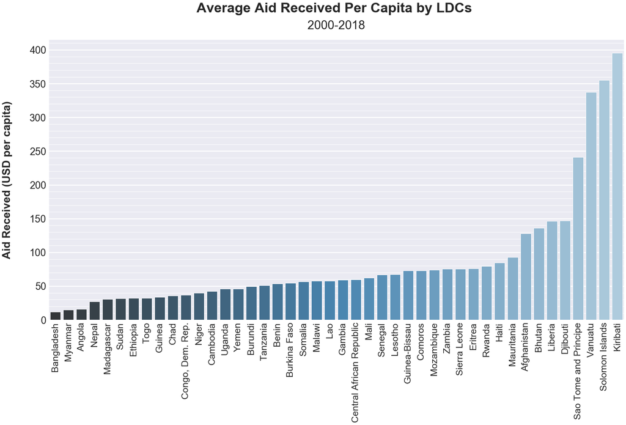

```python
# Now let's plot.

plt.figure(figsize=(30,15))
sns.set_style('dark')
sns.barplot(x='country', y='ldc_means', data=df_ldc.reset_index(), palette='Blues_d')
plt.suptitle('Average Aid Received Per Capita by LDCs', fontsize=40, fontweight='semibold', x=0.51)
plt.title('2000-2018', fontsize=35, pad=30)
plt.xticks(rotation=90, fontsize=27)
plt.xlabel('')
plt.yticks(fontsize=29)
plt.ylabel('Aid Received (USD per capita)', fontsize=32, labelpad=50, fontweight='semibold')
plt.grid(axis='y', which='major', linewidth=2.7)
plt.grid(axis='y', which='minor', linewidth=1.2)
plt.rc('axes', axisbelow=True)
plt.minorticks_on();
```

> Note that even within LDC countries, there is still a large distribution of the amount of aid received per capita. I think this further validates the approach of spliting the LDC countries into upper and lower quartiles. Because based on their correlations, you will be able to tell how the actual amount per capita is affecting development.

### Research Questions 1 & 2

> Since, the data has already been seperated into two groups, upper quartile foreign aid per capita and lower quartile foreign aid per capita, I will be able to answer both of my research questions simultaneously. I will use my visualizations to compute correlations, while also comparing these correlations between upper quartile and lower quartile countries.

> First we can calculate the average amount of aid per capita each group received collectively per year. These will be the x-values we can use in our scatter plots to find our correlations.

```python
# Average aid received per year by countries in the upper quartile.
avg_aid_upper = df_upper.mean()
avg_aid_upper
```

```
2000    105.722727
2001     95.663636
2002     97.100000
2003    110.118182
2004    122.190909
2005    151.890909
2006    157.063636
2007    217.063636
2008    231.063636
2009    206.136364
2010    270.909091
2011    284.636364
2012    264.936364
2013    243.745455
2014    238.245455
2015    254.718182
2016    213.936364
2017    221.472727
2018    217.200000
dtype: float64
```

```python
# Average aid received per year by countries in the lower quartile.
avg_aid_lower = df_lower.mean()
avg_aid_lower
```

```
2000    11.907273
2001    14.143636
2002    16.692727
2003    27.087273
2004    29.494545
2005    25.314545
2006    22.906364
2007    25.447273
2008    33.018182
2009    32.445455
2010    30.900000
2011    34.613636
2012    29.473636
2013    34.936364
2014    28.058182
2015    30.145455
2016    28.687273
2017    31.844545
2018    34.700000
dtype: float64
```

> Now that we have found the average aid received by each group of LDC countries, those in the upper and lower quartiles, we can now do the same thing with each variable, and then plot these mean values against each other. Let's first look at HDI.

```python
# average hdi per year for upper countries
avg_hdi_upper = df_hdi_upper.mean().round(3)
avg_hdi_upper
```

```
2000    0.442
2001    0.445
2002    0.452
2003    0.453
2004    0.463
2005    0.469
2006    0.478
2007    0.485
2008    0.491
2009    0.497
2010    0.502
2011    0.509
2012    0.514
2013    0.520
2014    0.522
2015    0.524
dtype: float64
```

> Why is 2016 to 2018 not being calculated? Let's check the dtypes of each column..

```python
# Ok, so 2016-2018 were strings, so let's change those to floats.

df_hdi_upper = df_hdi_upper.apply(lambda columns: columns.astype(np.float64))
df_hdi_upper.info()
```

```
<class 'pandas.core.frame.DataFrame'>
Index: 11 entries, Afghanistan to Vanuatu
Data columns (total 19 columns):
 #   Column  Non-Null Count  Dtype
---  ------  --------------  -----
 0   2000    11 non-null     float64
 1   2001    11 non-null     float64
 2   2002    11 non-null     float64
 3   2003    11 non-null     float64
 4   2004    11 non-null     float64
 5   2005    11 non-null     float64
 6   2006    11 non-null     float64
 7   2007    11 non-null     float64
 8   2008    11 non-null     float64
 9   2009    11 non-null     float64
 10  2010    11 non-null     float64
 11  2011    11 non-null     float64
 12  2012    11 non-null     float64
 13  2013    11 non-null     float64
 14  2014    11 non-null     float64
 15  2015    11 non-null     float64
 16  2016    11 non-null     float64
 17  2017    11 non-null     float64
 18  2018    11 non-null     float64
dtypes: float64(19)
memory usage: 1.7+ KB
```

> Let's do the same thing for hdi_lower.

```python
df_hdi_lower = df_hdi_lower.apply(lambda columns: columns.astype(np.float64))
df_hdi_lower.info()
```

```
<class 'pandas.core.frame.DataFrame'>
Index: 11 entries, Angola to Togo
Data columns (total 19 columns):
 #   Column  Non-Null Count  Dtype
---  ------  --------------  -----
 0   2000    11 non-null     float64
 1   2001    11 non-null     float64
 2   2002    11 non-null     float64
 3   2003    11 non-null     float64
 4   2004    11 non-null     float64
 5   2005    11 non-null     float64
 6   2006    11 non-null     float64
 7   2007    11 non-null     float64
 8   2008    11 non-null     float64
 9   2009    11 non-null     float64
 10  2010    11 non-null     float64
 11  2011    11 non-null     float64
 12  2012    11 non-null     float64
 13  2013    11 non-null     float64
 14  2014    11 non-null     float64
 15  2015    11 non-null     float64
 16  2016    11 non-null     float64
 17  2017    11 non-null     float64
 18  2018    11 non-null     float64
dtypes: float64(19)
memory usage: 1.7+ KB
```

> Now lets try to find the means again..

```python
# average hdi per year for upper quartile countries, second try.
avg_hdi_upper = df_hdi_upper.mean().round(3)
avg_hdi_upper
```

```
2000    0.442
2001    0.445
2002    0.452
2003    0.453
2004    0.463
2005    0.469
2006    0.478
2007    0.485
2008    0.491
2009    0.497
2010    0.502
2011    0.509
2012    0.514
2013    0.520
2014    0.522
2015    0.524
2016    0.541
2017    0.545
2018    0.548
dtype: float64
```

```python
# average hdi per year for lower quartile countries.
avg_hdi_lower = df_hdi_lower.mean().round(3)
avg_hdi_lower
```

```
2000    0.386
2001    0.392
2002    0.396
2003    0.402
2004    0.411
2005    0.419
2006    0.428
2007    0.438
2008    0.446
2009    0.455
2010    0.462
2011    0.471
2012    0.478
2013    0.484
2014    0.488
2015    0.492
2016    0.510
2017    0.514
2018    0.517
dtype: float64
```

> There we go!

> Let's call avg_aid values just so they are within sight.

```python
avg_aid_upper, avg_aid_lower
```

```
(2000    105.722727
 2001     95.663636
 2002     97.100000
 2003    110.118182
 2004    122.190909
 2005    151.890909
 2006    157.063636
 2007    217.063636
 2008    231.063636
 2009    206.136364
 2010    270.909091
 2011    284.636364
 2012    264.936364
 2013    243.745455
 2014    238.245455
```

[output cut: 25 more lines]

> Now that we have our values, I believe that we can start to plot now. My idea is to plot these seperately on a single figure with 2 axes, so that they are easily comparable. And then we can calculate the corrrelation coeficients to see how aid and hdi are realated among the two groups, upper and lower.

```python
# first let's calculate the corrcoef from each plot, so that we can put it on the plot.

hdi_corr_upper = avg_aid_upper.corr(avg_hdi_upper, method='pearson')
hdi_corr_lower = avg_aid_lower.corr(avg_hdi_lower, method='pearson')
hdi_corr_upper, hdi_corr_lower
```

```
(0.8070087360673163, 0.7495220007344318)
```

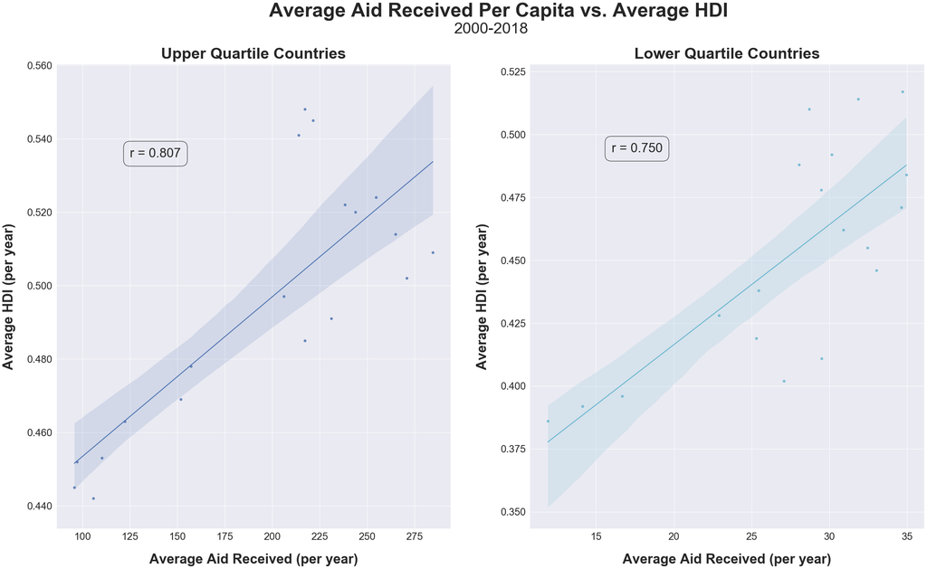

```python
from matplotlib.ticker import FormatStrFormatter

sns.set()
fig, (ax1, ax2) = plt.subplots(1, 2, figsize=(40,22))
sns.regplot(avg_aid_upper, avg_hdi_upper, ax=ax1, color='b')
sns.regplot(avg_aid_lower, avg_hdi_lower, ax=ax2, color='c')
ax1.tick_params(axis='both', which='both', labelsize=26)
ax1.yaxis.set_major_formatter(FormatStrFormatter('%.3f'))
ax2.yaxis.set_major_formatter(FormatStrFormatter('%.3f'))
ax2.tick_params(axis='both', which='both', labelsize=26)
fig.suptitle('Average Aid Received Per Capita vs. Average HDI', fontsize=50, fontweight='semibold', x=0.52)
plt.figtext(x=0.48, y=0.93, s='2000-2018', fontsize=40)
ax1.text(x=125, y=0.535, s='r = 0.807', fontsize=33, bbox=dict(facecolor='none', edgecolor='black', boxstyle='round,pad=0.5'))
ax2.text(x=16, y=0.493, s='r = 0.750', fontsize=33, bbox=dict(facecolor='none', edgecolor='black', boxstyle='round,pad=0.5'))
ax1.set_title('Upper Quartile Countries', fontsize=40, fontweight='semibold', pad=15)
ax2.set_title('Lower Quartile Countries', fontsize=40, fontweight='semibold', pad=15)
ax1.set_ylabel('Average HDI (per year)', fontsize=35, fontweight='semibold', labelpad=30)
ax2.set_ylabel('Average HDI (per year)', fontsize=35, fontweight='semibold', labelpad=30)
ax1.set_xlabel('Average Aid Received (per year)', fontsize=35, fontweight='semibold', labelpad=30)
ax2.set_xlabel('Average Aid Received (per year)', fontsize=35, fontweight='semibold', labelpad=30);
```

> Interesting, we see a nice positive correlation between aid received and HDI between both groups, upper and lower quartile countries, which answers our first research question. Although the correlation is slightly stronger among the upper quartile countries, I don't think there is a statistically significant difference between to two, therfore the answer to our second question, at least for HDI, is no. The amount of aid per capita a country receives doesn't seem to have a significant effect on their development.

> Let's now take a look at the Gini coefficient.

```python
# average gini per year for upper quartile countries.
avg_gini_upper = df_gini_upper.mean().round(1)
avg_gini_upper
```

```
2000    41.1
2001    41.2
2002    41.3
2003    41.3
2004    41.2
2005    41.1
2006    40.9
2007    40.6
2008    40.3
2009    39.9
2010    39.6
2011    39.3
2012    39.0
2013    38.8
2014    38.6
2015    38.5
2016    38.5
2017    38.4
2018    38.4
dtype: float64
```

```python
# average gini per year for lower quartile countries.
avg_gini_lower = df_gini_lower.mean().round(1)
avg_gini_lower
```

```
2000    40.4
2001    40.4
2002    40.3
2003    40.1
2004    39.8
2005    39.5
2006    39.2
2007    38.9
2008    38.8
2009    38.7
2010    38.6
2011    38.5
2012    38.5
2013    38.5
2014    38.5
2015    38.6
2016    38.6
2017    38.6
2018    38.7
dtype: float64
```

```python
# first let's calculate the corrcoef from each plot, so that we can put it on the plot.
gini_corr_upper = avg_aid_upper.corr(avg_gini_upper, method='pearson')
gini_corr_lower = avg_aid_lower.corr(avg_gini_lower, method='pearson')
gini_corr_upper, gini_corr_lower
```

```
(-0.8073250199881262, -0.8298057981688872)
```

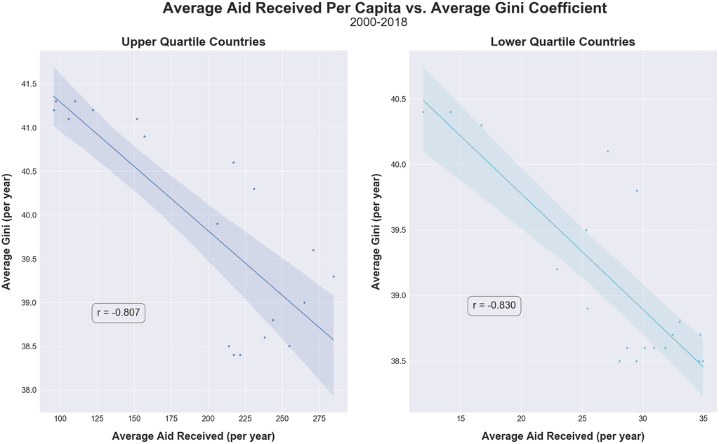

```python
# Plot

sns.set()
fig, (ax1, ax2) = plt.subplots(1, 2, figsize=(40,22))
sns.regplot(avg_aid_upper, avg_gini_upper, ax=ax1, color='b')
sns.regplot(avg_aid_lower, avg_gini_lower, ax=ax2, color='c')
ax1.tick_params(axis='both', which='both', labelsize=26)
ax2.tick_params(axis='both', which='both', labelsize=26)
fig.suptitle('Average Aid Received Per Capita vs. Average Gini Coefficient', fontsize=50, fontweight='semibold', x=0.52)
plt.figtext(x=0.48, y=0.93, s='2000-2018', fontsize=40)
ax1.text(x=125, y=38.85, s='r = -0.807', fontsize=33, bbox=dict(facecolor='none', edgecolor='black', boxstyle='round,pad=0.5'))
ax2.text(x=16, y=38.9, s='r = -0.830', fontsize=33, bbox=dict(facecolor='none', edgecolor='black', boxstyle='round,pad=0.5'))
ax1.set_title('Upper Quartile Countries', fontsize=40, fontweight='semibold', pad=15)
ax2.set_title('Lower Quartile Countries', fontsize=40, fontweight='semibold', pad=15)
ax1.set_ylabel('Average Gini (per year)', fontsize=35, fontweight='semibold', labelpad=30)
ax2.set_ylabel('Average Gini (per year)', fontsize=35, fontweight='semibold', labelpad=30)
ax1.set_xlabel('Average Aid Received (per year)', fontsize=35, fontweight='semibold', labelpad=30)
ax2.set_xlabel('Average Aid Received (per year)', fontsize=35, fontweight='semibold', labelpad=30);
```

> Here we see a negative correlation, which is what we would expect, since gini represents income inequality. The lower gini is, the better. I would consider this a 'postive' correlation in terms of answering the first research question. Very similar correlations here again, which suggests that being in the upper quartile or lower quartile doesn't have much impact on development.

> Lastly, let's take a look at Fertility rates.

```python
# average fertility rate per year for upper quartile countries.
avg_fertility_upper = df_fertility_upper.mean().round(2)
avg_fertility_upper
```

```
2000    5.02
2001    4.93
2002    4.84
2003    4.75
2004    4.66
2005    4.58
2006    4.49
2007    4.41
2008    4.32
2009    4.24
2010    4.16
2011    4.08
2012    4.00
2013    3.92
2014    3.85
2015    3.78
2016    3.71
2017    3.65
2018    3.59
dtype: float64
```

```python
# average fertility rate per year for lower quartile countries.
avg_fertility_lower = df_fertility_lower.mean().round(2)
avg_fertility_lower
```

```
2000    5.46
2001    5.38
2002    5.31
2003    5.23
2004    5.14
2005    5.06
2006    4.98
2007    4.89
2008    4.81
2009    4.73
2010    4.65
2011    4.57
2012    4.49
2013    4.42
2014    4.35
2015    4.28
2016    4.22
2017    4.15
2018    4.09
dtype: float64
```

```python
# calculate the corrcoef for each plot.
fertility_corr_upper = avg_aid_upper.corr(avg_fertility_upper, method='pearson')
fertility_corr_lower = avg_aid_lower.corr(avg_fertility_lower, method='pearson')
fertility_corr_upper, fertility_corr_lower
```

```
(-0.8184821221584632, -0.7635354867219261)
```

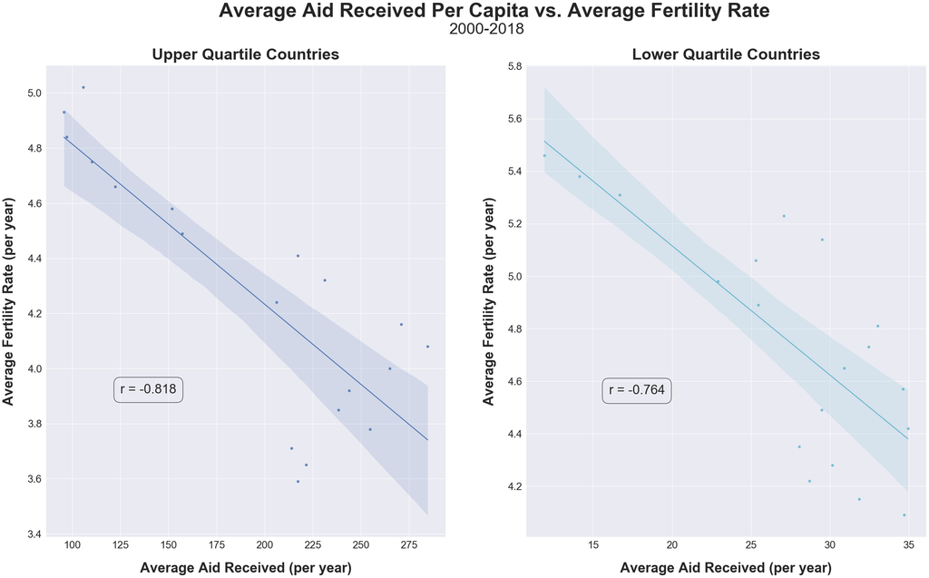

```python
# Plot

sns.set()
fig, (ax1, ax2) = plt.subplots(1, 2, figsize=(40,22))
sns.regplot(avg_aid_upper, avg_fertility_upper, ax=ax1, color='b')
sns.regplot(avg_aid_lower, avg_fertility_lower, ax=ax2, color='c')
ax1.tick_params(axis='both', which='both', labelsize=26)
ax2.tick_params(axis='both', which='both', labelsize=26)
fig.suptitle('Average Aid Received Per Capita vs. Average Fertility Rate', fontsize=50, fontweight='semibold', x=0.52)
plt.figtext(x=0.48, y=0.93, s='2000-2018', fontsize=40)
ax1.text(x=125, y=3.91, s='r = -0.818', fontsize=33, bbox=dict(facecolor='none', edgecolor='black', boxstyle='round,pad=0.5'))
ax2.text(x=16, y=4.55, s='r = -0.764', fontsize=33, bbox=dict(facecolor='none', edgecolor='black', boxstyle='round,pad=0.5'))
ax1.set_title('Upper Quartile Countries', fontsize=40, fontweight='semibold', pad=15)
ax2.set_title('Lower Quartile Countries', fontsize=40, fontweight='semibold', pad=15)
ax1.set_ylabel('Average Fertility Rate (per year)', fontsize=35, fontweight='semibold', labelpad=30)
ax2.set_ylabel('Average Fertility Rate (per year)', fontsize=35, fontweight='semibold', labelpad=30)
ax1.set_xlabel('Average Aid Received (per year)', fontsize=35, fontweight='semibold', labelpad=30)
ax2.set_xlabel('Average Aid Received (per year)', fontsize=35, fontweight='semibold', labelpad=30);
```

> And with Fertility rates we see the same kind of correlation as Gini. Negative correlation, which makes sense, since a decreasing fertility rate is associated with higher economic development. Again, the correlations between upper and lower quartiles are a bit more seperated, however not enough to make the claim that receiving more or less foreign aid per capita affects development in a significant way.

## Conclusions

#### Research Question 1:

> Based on the statistical data and visualizations, I think it would be fair to say that at the very least, as the amount of foreign aid per capita increases other economic indicators also increase. Which is to say that they don't decrease. In other words, although we can't say that more aid results in higher development, I think we can say that more aid doesn't negatively affect development, which is good right?

#### Limitations

> I think the biggest limitation here is fairly obvious. There isn't even close enough amount of statistical analysis here to make any sort of statement about the relationships between foreign aid and developing countries. In addition, taking the apporoach of comparing upper and lower quartiles may have also hindered my analysis is some way. With that said, this project was really fun to do!